# Project: Identify Customer Segments

In this project, you will apply unsupervised learning techniques to identify segments of the population that form the core customer base for a mail-order sales company in Germany. These segments can then be used to direct marketing campaigns towards audiences that will have the highest expected rate of returns. The data that you will use has been provided by our partners at Bertelsmann Arvato Analytics, and represents a real-life data science task.

This notebook will help you complete this task by providing a framework within which you will perform your analysis steps. In each step of the project, you will see some text describing the subtask that you will perform, followed by one or more code cells for you to complete your work. **Feel free to add additional code and markdown cells as you go along so that you can explore everything in precise chunks.** The code cells provided in the base template will outline only the major tasks, and will usually not be enough to cover all of the minor tasks that comprise it.

It should be noted that while there will be precise guidelines on how you should handle certain tasks in the project, there will also be places where an exact specification is not provided. **There will be times in the project where you will need to make and justify your own decisions on how to treat the data.** These are places where there may not be only one way to handle the data. In real-life tasks, there may be many valid ways to approach an analysis task. One of the most important things you can do is clearly document your approach so that other scientists can understand the decisions you've made.

At the end of most sections, there will be a Markdown cell labeled **Discussion**. In these cells, you will report your findings for the completed section, as well as document the decisions that you made in your approach to each subtask. **Your project will be evaluated not just on the code used to complete the tasks outlined, but also your communication about your observations and conclusions at each stage.**

### Project Summary

This section summarizes the approach and the results of this project.

**Project Goal**

- In this project, unsupervised learning techniques are applied to identify segments of the population that form the core customer base for a mail-order sales company in Germany.
- The dataset has 85 features and 891221 entries, i.e., rows (about 1% of Germanys population).
- These segments can then be used to direct marketing campaigns towards audiences that will have the highest expected rate of returns.

**Preprocessing**

- The data is loaded and the missing or unknown values are evaluated (see 0).
- Missing or unknown values in the columns are investigated. To improve data quality, 4 clomns are dropped (see 1.1.2).
- Missing or unknown values in the rows are investigated. To improve data quality, rows with more than 10 missing or unknown values are dropped (see 1.1.3).
- The categorical features are evaluated. Binary categorical features with numeric values are kept without modification. Binary categorical features with non-numeric values are re-encoded. Multi-level categorical features are drop from the analysis (see 1.2.1).
- The mixed featured are evaluated. Two mixed features are separated into two dimensions. The remaining four mixed features are dropped for various reasons (see 1.2.2).
- A cleaning function is written to apply the above steps to clean and prepare the data for analysis (see 1.3).

**Feature Transformation**

- All occurrences of missing values encoded as np.nan are replaced by the mean of the corresponding column using the scikit-learn imputer function. The data is scaled using the scikit-learn StandardScaler function, scaling each feature to mean 0 and standard deviation 1. (see 2.1).
- Dimensionality reduction is performed using scikit-learn Principal Component Analysis (PCA), reducing the dataset from 66 features to 33 features while retaining approx. 90% of the information (see 2.2).

**Clustering & Analysis**

- Clustering is applied to the principal component space of the general population dataset. The number of clusters equals 10 reduces the average within-cluster distances without increasing computational cost too much (see 3.1).
- Correspondingly, the customer dataset is loaded, cleaned, imputed, scaled, principal component analysis is applied and clustering is applied to the principal component space of the customer dataset (see 3.2).
- The resulting predictions of the clustering model yields clustering centroids for each cluster. The centroids of each cluster allows to run an inverse transform to transform the centroids all the way back to the original feature space in order to compare the predictions of the different clusters to the original features space of the general population data (see 3.3).
- Finally, the clusters of the general population dataset and the customer dataset are compared to find, relative to the general population dataset, an overrepresented customer segment as well as an underrepresented customer segment (see 3.3).

**Conclusion**

- **Cluster 5** is **overrepresented** in the customer dataset compared to the general population dataset. This overrepresented customer group is populated by **middle-aged** people, living in **prosperous, high-income households** and has a **high share living in 1-2 family homes** compared to the general population (see 3.3).
- **Cluster 4** is **underrepresented** in the customer dataset compared to the general population dataset. This underrepresented customer group is **quite younger**, living in **less affluent, lower income households** and lives in **highly densely populated areas** compared to the general population (see 3.3).
- **Cluster 9** is **underrepresented** in the customer dataset compared to the general population dataset. This underrepresented customer group is **quite younger**, living in **comfortable to prosperous, average-income households** and lives in **lower densely populated areas** compared to the general population (see 3.3).

```python
# import libraries here; add more as necessary
import numpy as np
import pandas as pd
import matplotlib.pyplot as plt
import seaborn as sns
from sklearn.preprocessing import Imputer, StandardScaler
from sklearn.decomposition import PCA
from sklearn.cluster import KMeans

# magic word for producing visualizations in notebook
%matplotlib inline

'''
Import note: The classroom currently uses sklearn version 0.19.
If you need to use an imputer, it is available in sklearn.preprocessing.Imputer,
instead of sklearn.impute as in newer versions of sklearn.
'''
```

```
'\nImport note: The classroom currently uses sklearn version 0.19.\nIf you need to use an imputer, it is available in sklearn.preprocessing.Imputer,\ninstead of sklearn.impute as in newer versions of sklearn.\n'
```

### Step 0: Load the Data

There are four files associated with this project (not including this one):

Each row of the demographics files represents a single person, but also includes information outside of individuals, including information about their household, building, and neighborhood. You will use this information to cluster the general population into groups with similar demographic properties. Then, you will see how the people in the customers dataset fit into those created clusters. The hope here is that certain clusters are over-represented in the customers data, as compared to the general population; those over-represented clusters will be assumed to be part of the core userbase. This information can then be used for further applications, such as targeting for a marketing campaign.

To start off with, load in the demographics data for the general population into a pandas DataFrame, and do the same for the feature attributes summary. Note for all of the `.csv` data files in this project: they're semicolon (`;`) delimited, so you'll need an additional argument in your [`read_csv()`](https://pandas.pydata.org/pandas-docs/stable/generated/pandas.read_csv.html) call to read in the data properly. Also, considering the size of the main dataset, it may take some time for it to load completely.

Once the dataset is loaded, it's recommended that you take a little bit of time just browsing the general structure of the dataset and feature summary file. You'll be getting deep into the innards of the cleaning in the first major step of the project, so gaining some general familiarity can help you get your bearings.

```python
# Load in the general demographics data.
azdias = pd.read_csv('Udacity_AZDIAS_Subset.csv', sep = ';')
```

```python
# Make a copy of the original dataset
azdias_original_df = pd.read_csv('Udacity_AZDIAS_Subset.csv', sep = ';')
```

```python
# Check the structure of the data after it's loaded (e.g. print the number of
# rows and columns, print the first few rows).
azdias.head()
```

|  | AGER_TYP | ALTERSKATEGORIE_GROB | ANREDE_KZ | CJT_GESAMTTYP | FINANZ_MINIMALIST | FINANZ_SPARER | FINANZ_VORSORGER | FINANZ_ANLEGER | FINANZ_UNAUFFAELLIGER | FINANZ_HAUSBAUER | ... | PLZ8_ANTG1 | PLZ8_ANTG2 | PLZ8_ANTG3 | PLZ8_ANTG4 | PLZ8_BAUMAX | PLZ8_HHZ | PLZ8_GBZ | ARBEIT | ORTSGR_KLS9 | RELAT_AB |
| --- | --- | --- | --- | --- | --- | --- | --- | --- | --- | --- | --- | --- | --- | --- | --- | --- | --- | --- | --- | --- | --- |
| 0 | -1 | 2 | 1 | 2.0 | 3 | 4 | 3 | 5 | 5 | 3 | ... | NaN | NaN | NaN | NaN | NaN | NaN | NaN | NaN | NaN | NaN |
| 1 | -1 | 1 | 2 | 5.0 | 1 | 5 | 2 | 5 | 4 | 5 | ... | 2.0 | 3.0 | 2.0 | 1.0 | 1.0 | 5.0 | 4.0 | 3.0 | 5.0 | 4.0 |
| 2 | -1 | 3 | 2 | 3.0 | 1 | 4 | 1 | 2 | 3 | 5 | ... | 3.0 | 3.0 | 1.0 | 0.0 | 1.0 | 4.0 | 4.0 | 3.0 | 5.0 | 2.0 |
| 3 | 2 | 4 | 2 | 2.0 | 4 | 2 | 5 | 2 | 1 | 2 | ... | 2.0 | 2.0 | 2.0 | 0.0 | 1.0 | 3.0 | 4.0 | 2.0 | 3.0 | 3.0 |
| 4 | -1 | 3 | 1 | 5.0 | 4 | 3 | 4 | 1 | 3 | 2 | ... | 2.0 | 4.0 | 2.0 | 1.0 | 2.0 | 3.0 | 3.0 | 4.0 | 6.0 | 5.0 |

5 rows × 85 columns

```python
# Evaluate descriptive statistics
azdias.describe()
```

|  | AGER_TYP | ALTERSKATEGORIE_GROB | ANREDE_KZ | CJT_GESAMTTYP | FINANZ_MINIMALIST | FINANZ_SPARER | FINANZ_VORSORGER | FINANZ_ANLEGER | FINANZ_UNAUFFAELLIGER | FINANZ_HAUSBAUER | ... | PLZ8_ANTG1 | PLZ8_ANTG2 | PLZ8_ANTG3 | PLZ8_ANTG4 | PLZ8_BAUMAX | PLZ8_HHZ | PLZ8_GBZ | ARBEIT | ORTSGR_KLS9 | RELAT_AB |
| --- | --- | --- | --- | --- | --- | --- | --- | --- | --- | --- | --- | --- | --- | --- | --- | --- | --- | --- | --- | --- | --- |
| count | 891221.000000 | 891221.000000 | 891221.000000 | 886367.000000 | 891221.000000 | 891221.000000 | 891221.000000 | 891221.000000 | 891221.000000 | 891221.000000 | ... | 774706.000000 | 774706.000000 | 774706.000000 | 774706.000000 | 774706.000000 | 774706.000000 | 774706.000000 | 794005.000000 | 794005.000000 | 794005.00000 |
| mean | -0.358435 | 2.777398 | 1.522098 | 3.632838 | 3.074528 | 2.821039 | 3.401106 | 3.033328 | 2.874167 | 3.075121 | ... | 2.253330 | 2.801858 | 1.595426 | 0.699166 | 1.943913 | 3.612821 | 3.381087 | 3.167854 | 5.293002 | 3.07222 |
| std | 1.198724 | 1.068775 | 0.499512 | 1.595021 | 1.321055 | 1.464749 | 1.322134 | 1.529603 | 1.486731 | 1.353248 | ... | 0.972008 | 0.920309 | 0.986736 | 0.727137 | 1.459654 | 0.973967 | 1.111598 | 1.002376 | 2.303739 | 1.36298 |
| min | -1.000000 | 1.000000 | 1.000000 | 1.000000 | 1.000000 | 1.000000 | 1.000000 | 1.000000 | 1.000000 | 1.000000 | ... | 0.000000 | 0.000000 | 0.000000 | 0.000000 | 1.000000 | 1.000000 | 1.000000 | 1.000000 | 0.000000 | 1.00000 |
| 25% | -1.000000 | 2.000000 | 1.000000 | 2.000000 | 2.000000 | 1.000000 | 3.000000 | 2.000000 | 2.000000 | 2.000000 | ... | 1.000000 | 2.000000 | 1.000000 | 0.000000 | 1.000000 | 3.000000 | 3.000000 | 3.000000 | 4.000000 | 2.00000 |
| 50% | -1.000000 | 3.000000 | 2.000000 | 4.000000 | 3.000000 | 3.000000 | 3.000000 | 3.000000 | 3.000000 | 3.000000 | ... | 2.000000 | 3.000000 | 2.000000 | 1.000000 | 1.000000 | 4.000000 | 3.000000 | 3.000000 | 5.000000 | 3.00000 |
| 75% | -1.000000 | 4.000000 | 2.000000 | 5.000000 | 4.000000 | 4.000000 | 5.000000 | 5.000000 | 4.000000 | 4.000000 | ... | 3.000000 | 3.000000 | 2.000000 | 1.000000 | 3.000000 | 4.000000 | 4.000000 | 4.000000 | 7.000000 | 4.00000 |
| max | 3.000000 | 9.000000 | 2.000000 | 6.000000 | 5.000000 | 5.000000 | 5.000000 | 5.000000 | 5.000000 | 5.000000 | ... | 4.000000 | 4.000000 | 3.000000 | 2.000000 | 5.000000 | 5.000000 | 5.000000 | 9.000000 | 9.000000 | 9.00000 |

8 rows × 81 columns

```python
# Evaluate shape
azdias.shape
```

```
(891221, 85)
```

```python
# Evaluate general information
azdias.info()
```

```
<class 'pandas.core.frame.DataFrame'>
RangeIndex: 891221 entries, 0 to 891220
Data columns (total 85 columns):
AGER_TYP                 891221 non-null int64
ALTERSKATEGORIE_GROB     891221 non-null int64
ANREDE_KZ                891221 non-null int64
CJT_GESAMTTYP            886367 non-null float64
FINANZ_MINIMALIST        891221 non-null int64
FINANZ_SPARER            891221 non-null int64
FINANZ_VORSORGER         891221 non-null int64
FINANZ_ANLEGER           891221 non-null int64
FINANZ_UNAUFFAELLIGER    891221 non-null int64
FINANZ_HAUSBAUER         891221 non-null int64
FINANZTYP                891221 non-null int64
GEBURTSJAHR              891221 non-null int64
GFK_URLAUBERTYP          886367 non-null float64
GREEN_AVANTGARDE         891221 non-null int64
HEALTH_TYP               891221 non-null int64
LP_LEBENSPHASE_FEIN      886367 non-null float64
LP_LEBENSPHASE_GROB      886367 non-null float64
LP_FAMILIE_FEIN          886367 non-null float64
LP_FAMILIE_GROB          886367 non-null float64
LP_STATUS_FEIN           886367 non-null float64
LP_STATUS_GROB           886367 non-null float64
NATIONALITAET_KZ         891221 non-null int64
PRAEGENDE_JUGENDJAHRE    891221 non-null int64
RETOURTYP_BK_S           886367 non-null float64
SEMIO_SOZ                891221 non-null int64
SEMIO_FAM                891221 non-null int64
SEMIO_REL                891221 non-null int64
SEMIO_MAT                891221 non-null int64
SEMIO_VERT               891221 non-null int64
SEMIO_LUST               891221 non-null int64
SEMIO_ERL                891221 non-null int64
SEMIO_KULT               891221 non-null int64
SEMIO_RAT                891221 non-null int64
SEMIO_KRIT               891221 non-null int64
SEMIO_DOM                891221 non-null int64
SEMIO_KAEM               891221 non-null int64
SEMIO_PFLICHT            891221 non-null int64
```

[output cut: 35 more lines]

```
ONLINE_AFFINITAET        886367 non-null float64
REGIOTYP                 770025 non-null float64
KBA13_ANZAHL_PKW         785421 non-null float64
PLZ8_ANTG1               774706 non-null float64
PLZ8_ANTG2               774706 non-null float64
PLZ8_ANTG3               774706 non-null float64
PLZ8_ANTG4               774706 non-null float64
PLZ8_BAUMAX              774706 non-null float64
PLZ8_HHZ                 774706 non-null float64
PLZ8_GBZ                 774706 non-null float64
ARBEIT                   794005 non-null float64
ORTSGR_KLS9              794005 non-null float64
RELAT_AB                 794005 non-null float64
dtypes: float64(49), int64(32), object(4)
memory usage: 578.0+ MB
```

```python
# Load in the feature summary file. Use ';' to separate the columns.
feat_info = pd.read_csv('AZDIAS_Feature_Summary.csv',sep = ';')
```

```python
# Check the structure of the data after it's loaded (e.g. print the number of
# rows and columns, print the first few rows).
feat_info.head()
```

|  | attribute | information_level | type | missing_or_unknown |
| --- | --- | --- | --- | --- |
| 0 | AGER_TYP | person | categorical | [-1,0] |
| 1 | ALTERSKATEGORIE_GROB | person | ordinal | [-1,0,9] |
| 2 | ANREDE_KZ | person | categorical | [-1,0] |
| 3 | CJT_GESAMTTYP | person | categorical | [0] |
| 4 | FINANZ_MINIMALIST | person | ordinal | [-1] |

```python
# Evaluate descriptive statistics
feat_info.describe()
```

|  | attribute | information_level | type | missing_or_unknown |
| --- | --- | --- | --- | --- |
| count | 85 | 85 | 85 | 85 |
| unique | 85 | 9 | 5 | 9 |
| top | HH_EINKOMMEN_SCORE | person | ordinal | [-1] |
| freq | 1 | 43 | 49 | 26 |

```python
# Evaluate shape
feat_info.shape
```

```
(85, 4)
```

```python
# Evaluate general information
feat_info.info()
```

```
<class 'pandas.core.frame.DataFrame'>
RangeIndex: 85 entries, 0 to 84
Data columns (total 4 columns):
attribute             85 non-null object
information_level     85 non-null object
type                  85 non-null object
missing_or_unknown    85 non-null object
dtypes: object(4)
memory usage: 2.7+ KB
```

> **Tip**: Add additional cells to keep everything in reasonably-sized chunks! Keyboard shortcut `esc --> a` (press escape to enter command mode, then press the 'A' key) adds a new cell before the active cell, and `esc --> b` adds a new cell after the active cell. If you need to convert an active cell to a markdown cell, use `esc --> m` and to convert to a code cell, use `esc --> y`.

## Step 1: Preprocessing

### Step 1.1: Assess Missing Data

The feature summary file contains a summary of properties for each demographics data column. You will use this file to help you make cleaning decisions during this stage of the project. First of all, you should assess the demographics data in terms of missing data. Pay attention to the following points as you perform your analysis, and take notes on what you observe. Make sure that you fill in the **Discussion** cell with your findings and decisions at the end of each step that has one!

#### Step 1.1.1: Convert Missing Value Codes to NaNs

The fourth column of the feature attributes summary (loaded in above as `feat_info`) documents the codes from the data dictionary that indicate missing or unknown data. While the file encodes this as a list (e.g. `[-1,0]`), this will get read in as a string object. You'll need to do a little bit of parsing to make use of it to identify and clean the data. Convert data that matches a 'missing' or 'unknown' value code into a numpy NaN value. You might want to see how much data takes on a 'missing' or 'unknown' code, and how much data is naturally missing, as a point of interest.

**As one more reminder, you are encouraged to add additional cells to break up your analysis into manageable chunks.**

```python
# Evaluate total of missing values before replacing
print('Number of naturally missing values: ',azdias.isnull().sum().sum())
```

```
Number of naturally missing values:  4896838
```

```python
# Identify missing or unknown data values and convert them to NaNs.
for idx in range(feat_info.shape[0]): # Iterate through feat_info
    attribute = feat_info['attribute'][idx] # Assign attribute of current iteration to variable
    elements = feat_info['missing_or_unknown'][idx] # Assign elements of current iteration to variable (type: str)
    elements = elements.strip('[').strip(']').split(',') # Strip brackets and split string (type: list)
    elements = [int(indicator) if indicator.isdigit() else indicator for indicator in elements] # Convert non-negative numbers into int
    elements = [-1 if indicator == '-1' else indicator for indicator in elements] # Set '-1' to -1
    elements = [ None if indicator == '' else indicator for indicator in elements] # Set None for an empty list

    for indicator in elements:
        replace_dict = {attribute: indicator}
        azdias.replace(replace_dict, np.nan, inplace=True) # Set value to NaN
```

```python
# Evaluate total of missing values before replacing
print('Number of missing values after conversion: ',azdias.isnull().sum().sum())
```

```
Number of missing values after conversion:  8373929
```

#### Discussion

This paragraph discusses the findings after conversion. Key value:

- There are total 891221 x 85 = 75'753'785 values.
- There are 4'896'838 naturally missing values, or 6.5% of the total values.
- There are 8'373'929 missing values after conversion, or 11% of the total values.

After conversion, 11% of the total values are missing or unknwon. This is a significant amount. We have to investigate which attributes contribute most to the 11% and evaluate how much information they contribute. Maybe it is possible to drop some attributes and get the total precentage of missing or unknown values closer to 5% or even below.

#### Step 1.1.2: Assess Missing Data in Each Column

How much missing data is present in each column? There are a few columns that are outliers in terms of the proportion of values that are missing. You will want to use matplotlib's [`hist()`](https://matplotlib.org/api/_as_gen/matplotlib.pyplot.hist.html) function to visualize the distribution of missing value counts to find these columns. Identify and document these columns. While some of these columns might have justifications for keeping or re-encoding the data, for this project you should just remove them from the dataframe. (Feel free to make remarks about these outlier columns in the discussion, however!)

For the remaining features, are there any patterns in which columns have, or share, missing data?

```python
# Perform an assessment of how much missing data there is in each column of the dataset.
# Evaluate missing values post conversion: check for Nan, sum them up for each column, convert to dataframe, transpose
count_missing_unknown_col = azdias.isnull().sum().to_frame().T

# Create a dataframe for sorting and analysis (I was not able to sort the above dataframe)
x = count_missing_unknown_col.columns.tolist() # List of attributes
y = count_missing_unknown_col.loc[0,:] # counts of missing and unknown values
data_dict = {'attributes': x, 'missing_or_unknown': y} # Create dictionary with data for dataframe
count_missing_unknown_col = pd.DataFrame(data = data_dict).sort_values(by = ['missing_or_unknown'], ascending = False) # Create dataframe and sort counts of missing and unknown values
```

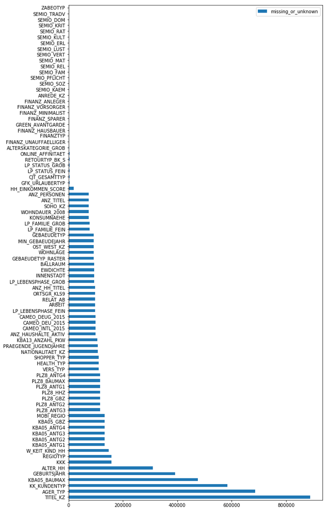

```python
# Plot vertical bar chart
count_missing_unknown_col.plot.barh(figsize = (10, 20))
```

```python
# Calculate the percentage to which each attribute contributes to the missing or unknown values
# Take the column of missing or unknwn, divid it by the total number of missing or unknwon and multiply by 100
missing_unknown_col_percent = count_missing_unknown_col['missing_or_unknown'] / count_missing_unknown_col['missing_or_unknown'].sum() * 100
# Add the column of missing or unknown in percnt to the dataframe
count_missing_unknown_col['missing_or_unknown_percent'] = missing_unknown_col_percent

# Calculate the cumulative contribution to which each attribute contributes to the missing or unknown values
# Add data to the
count_missing_unknown_col['mis_unk_cumsum_percent'] = count_missing_unknown_col['missing_or_unknown_percent'].cumsum()
```

```python
# View dataframe
count_missing_unknown_col.head(10)
```

|  | attributes | missing_or_unknown | missing_or_unknown_percent | mis_unk_cumsum_percent |
| --- | --- | --- | --- | --- |
| TITEL_KZ | TITEL_KZ | 889061 | 10.617011 | 10.617011 |
| AGER_TYP | AGER_TYP | 685843 | 8.190218 | 18.807229 |
| KK_KUNDENTYP | KK_KUNDENTYP | 584612 | 6.981335 | 25.788564 |
| KBA05_BAUMAX | KBA05_BAUMAX | 476524 | 5.690567 | 31.479130 |
| GEBURTSJAHR | GEBURTSJAHR | 392318 | 4.684993 | 36.164123 |
| ALTER_HH | ALTER_HH | 310267 | 3.705154 | 39.869278 |
| KKK | KKK | 158064 | 1.887573 | 41.756850 |
| REGIOTYP | REGIOTYP | 158064 | 1.887573 | 43.644423 |
| W_KEIT_KIND_HH | W_KEIT_KIND_HH | 147988 | 1.767247 | 45.411670 |
| KBA05_ANTG1 | KBA05_ANTG1 | 133324 | 1.592132 | 47.003802 |

```
Text(0.5,1,'Distribution for Selected Data')
```

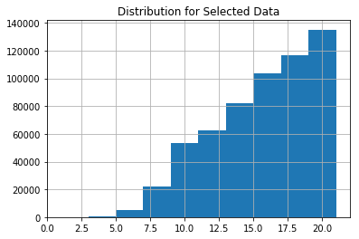

```python
# Plot histogram of specific attribute
azdias['ALTER_HH'].hist()
plt.title('Distribution for Selected Data')
```

```python
# Evaluate missing values of specific attribute
azdias['ALTER_HH'].isnull().sum()
```

```
310267
```

```python
# Remove the outlier columns from the dataset. (You'll perform other data engineering tasks such as re-encoding and imputation later.)
azdias.drop(columns = ['TITEL_KZ', 'AGER_TYP', 'KK_KUNDENTYP', 'KBA05_BAUMAX'], inplace = True)
```

```python
# Look at the dataframe with dropped attributes
azdias.head()
```

|  | ALTERSKATEGORIE_GROB | ANREDE_KZ | CJT_GESAMTTYP | FINANZ_MINIMALIST | FINANZ_SPARER | FINANZ_VORSORGER | FINANZ_ANLEGER | FINANZ_UNAUFFAELLIGER | FINANZ_HAUSBAUER | FINANZTYP | ... | PLZ8_ANTG1 | PLZ8_ANTG2 | PLZ8_ANTG3 | PLZ8_ANTG4 | PLZ8_BAUMAX | PLZ8_HHZ | PLZ8_GBZ | ARBEIT | ORTSGR_KLS9 | RELAT_AB |
| --- | --- | --- | --- | --- | --- | --- | --- | --- | --- | --- | --- | --- | --- | --- | --- | --- | --- | --- | --- | --- | --- |
| 0 | 2.0 | 1 | 2.0 | 3 | 4 | 3 | 5 | 5 | 3 | 4 | ... | NaN | NaN | NaN | NaN | NaN | NaN | NaN | NaN | NaN | NaN |
| 1 | 1.0 | 2 | 5.0 | 1 | 5 | 2 | 5 | 4 | 5 | 1 | ... | 2.0 | 3.0 | 2.0 | 1.0 | 1.0 | 5.0 | 4.0 | 3.0 | 5.0 | 4.0 |
| 2 | 3.0 | 2 | 3.0 | 1 | 4 | 1 | 2 | 3 | 5 | 1 | ... | 3.0 | 3.0 | 1.0 | 0.0 | 1.0 | 4.0 | 4.0 | 3.0 | 5.0 | 2.0 |
| 3 | 4.0 | 2 | 2.0 | 4 | 2 | 5 | 2 | 1 | 2 | 6 | ... | 2.0 | 2.0 | 2.0 | 0.0 | 1.0 | 3.0 | 4.0 | 2.0 | 3.0 | 3.0 |
| 4 | 3.0 | 1 | 5.0 | 4 | 3 | 4 | 1 | 3 | 2 | 5 | ... | 2.0 | 4.0 | 2.0 | 1.0 | 2.0 | 3.0 | 3.0 | 4.0 | 6.0 | 5.0 |

5 rows × 81 columns

```python
# Evaluate total of missing values before replacing
print('Number of missing values after dropping columns: ',azdias.isnull().sum().sum())
```

```
Number of missing values after dropping columns:  5737889
```

#### Discussion 1.1.2: Assess Missing Data in Each Column

This paragraph discusses the findings after assessing missing data in each column.

The top 6 contributors to missing or unknown values are following attributes.

- TITEL_KZ
- AGER_TYP
- KK_KUNDENTYP
- KBA05_BAUMAX
- GEBURTSJAHR
- ALTER_HH

They contribute to almost 40% of the missing or unknown values. Beyond these 6 attributes, the contribution to the missing or unknown values is quite uniformely distributed and indifferent. So we address the 6 attributes in more depth by looking at the data dictionary for identify customer segments data (Data_Dictionary.md).

#### Step 1.1.3: Assess Missing Data in Each Row

Now, you'll perform a similar assessment for the rows of the dataset. How much data is missing in each row? As with the columns, you should see some groups of points that have a very different numbers of missing values. Divide the data into two subsets: one for data points that are above some threshold for missing values, and a second subset for points below that threshold.

In order to know what to do with the outlier rows, we should see if the distribution of data values on columns that are not missing data (or are missing very little data) are similar or different between the two groups. Select at least five of these columns and compare the distribution of values.

- You can use seaborn's [`countplot()`](https://seaborn.pydata.org/generated/seaborn.countplot.html) function to create a bar chart of code frequencies and matplotlib's [`subplot()`](https://matplotlib.org/api/_as_gen/matplotlib.pyplot.subplot.html) function to put bar charts for the two subplots side by side.
- To reduce repeated code, you might want to write a function that can perform this comparison, taking as one of its arguments a column to be compared.

Depending on what you observe in your comparison, this will have implications on how you approach your conclusions later in the analysis. If the distributions of non-missing features look similar between the data with many missing values and the data with few or no missing values, then we could argue that simply dropping those points from the analysis won't present a major issue. On the other hand, if the data with many missing values looks very different from the data with few or no missing values, then we should make a note on those data as special. We'll revisit these data later on. **Either way, you should continue your analysis for now using just the subset of the data with few or no missing values.**

```python
# Perform an assessment of how much missing data there is in each row of the dataset.
# Evaluate missing values post conversion: check for Nan, sum them up for each row, convert to dataframe, transpose
count_missing_unknown_rows = azdias.isnull().sum(axis = 1).to_frame().T

# Create a dataframe for sorting and analysis
x = count_missing_unknown_rows.columns.tolist() # List of attributes
y = count_missing_unknown_rows.loc[0,:] # counts of missing and unknown values
data_dict = {'row': x, 'missing_or_unknown': y} # Create dictionary with data for dataframe
# Create a dataframe
count_missing_unknown_rows = pd.DataFrame(data = data_dict).sort_values(by = ['missing_or_unknown'], ascending = False)
```

```python
count_missing_unknown_rows.head()
```

|  | row | missing_or_unknown |
| --- | --- | --- |
| 732775 | 732775 | 50 |
| 643174 | 643174 | 50 |
| 665893 | 665893 | 49 |
| 798973 | 798973 | 49 |
| 477687 | 477687 | 49 |

```python
# Check sum. This values is to be the same as at the end of Section 1.1.2 after dropping the columns
count_missing_unknown_rows['missing_or_unknown'].sum()
```

```
5737889
```

```python
# Get the number of rows with zero missing or unknown values and print
num_rows_zero_missing = count_missing_unknown_rows['missing_or_unknown'].eq(0).sum()
print('There are {} rows with 0 missing or unknown values'.format(num_rows_zero_missing))

# Get the number of rows with missing or unknown values and print
num_rows_missing = len( count_missing_unknown_rows[count_missing_unknown_rows['missing_or_unknown'] > 0] )
print('There are {} rows with missing or unknown values'.format(num_rows_missing))

# Check sum that both values add up to the total number of rows
print('The above values add up to the total number of rows of {}'.format(num_rows_zero_missing + num_rows_missing))
```

```
There are 348158 rows with 0 missing or unknown values
There are 543063 rows with missing or unknown values
The above values add up to the total number of rows of 891221
```

```
Text(0,0.5,'Counts')
```

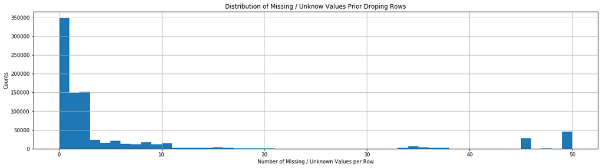

```python
# Plot the distribution of missing values prior droping rows
count_missing_unknown_rows['missing_or_unknown'].hist(bins = 50, figsize = (20, 5))
plt.title('Distribution of Missing / Unknow Values Prior Droping Rows')
plt.xlabel('Number of Missing / Unknown Values per Row')
plt.ylabel('Counts')
```

#### Drop Threshold

In the next couple of cells, I evaluate the drop threshold. If I set the acceptable limit of missing or unknwon per row to a given value, all rows with more missing or unknown per rwos will be dropped. I want to find a good drop threshold so I loose rows with high values of missing or unknown values, but I want to retain the most information.

For this purpose, I investigate the distribution of the missing or unknown values as well as the cumulative sum of the distribution of the missing or unknown values. The histogram values from count_missing_unknown_rows show how many rows have a given occurance of missing or unknown values. This allows to determine if there is an optimal drop threshold above which dropping rows with high occurance of missing or unknown values while keeping the most rows with little occurance of missing or unknown values.

```python
# Determine the histogram values from count_missing_unknown_rows
# Source of relevant code:
# https://stackoverflow.com/questions/32739526/histogram-values-from-pandas-dataframe
# df=  pd.concat([df[x].groupby(pd.cut(df[x],bins)).count() for x in df.columns],axis=1)
# hist_vector.index.names = [None]

# Create numpy array with bins for the histogram
bins = np.linspace(0, 50, 51, dtype = 'int')

# Get the histogram values from the dataframe (see source above)
hist_matrix = pd.concat([count_missing_unknown_rows[idx].groupby(pd.cut(count_missing_unknown_rows[idx], bins)).count() for idx in count_missing_unknown_rows.columns], axis = 1)

# Calculate cumulative sum of missing or unknown values from bottom up
# https://stackoverflow.com/questions/37872565/reversed-cumulative-sum-of-a-column-in-pandas-dataframe
# df['C']=df.A[::-1].cumsum()
hist_matrix['missing_or_unknown_cumsum'] = hist_matrix.loc[::-1, 'missing_or_unknown'].cumsum()

# Remove the last value to fit the dimensions of hist_matrix
bins = bins[:-1]
# Append bins to hist_matrix
hist_matrix['bins'] = bins
```

```python
# View head of dataframe
hist_matrix.head()
```

|  | row | missing_or_unknown | missing_or_unknown_cumsum | bins |
| --- | --- | --- | --- | --- |
| (0, 1] | 1 | 149093 | 543063 | 0 |
| (1, 2] | 1 | 151171 | 393970 | 1 |
| (2, 3] | 1 | 23896 | 242799 | 2 |
| (3, 4] | 1 | 15913 | 218903 | 3 |
| (4, 5] | 1 | 20963 | 202990 | 4 |

```
Text(0,0.5,'Counts')
```

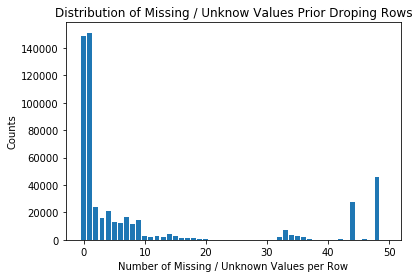

```python
# Plot histogram
plt.bar(hist_matrix['bins'], hist_matrix['missing_or_unknown'])
plt.title('Distribution of Missing / Unknow Values Prior Droping Rows')
plt.xlabel('Number of Missing / Unknown Values per Row')
plt.ylabel('Counts')
```

Sanity Check to see if the first histogram in Step 1.1.3 looks the same as the one here. The first bin of 0 missing or unknwos shown per row in the above histogram does not show up in the histogram here because of how the intervals are set in hist_matrix. Other than that, the histogram is equivalent and indicates that the bins and occurances are ok.

```
Text(0,0.5,'Expected Number of Dropped Values')
```

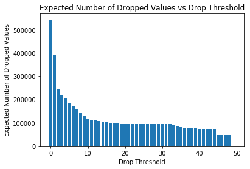

```python
# Plot histogram of cumulative values
plt.bar(hist_matrix['bins'], hist_matrix['missing_or_unknown_cumsum'])
plt.title('Expected Number of Dropped Values vs Drop Threshold')
plt.xlabel('Drop Threshold')
plt.ylabel('Expected Number of Dropped Values')
```

The above histogram shows two elbows.

- A conservative elbow occurs at 10. This means if I set the drop threshold to 10, i.e., if I drop all rows with more than 10 missing or unknown values, I drop about 120'000 rows with missing or unknown values.
- A progressiv elbow occurs at 2. This means if I set the drop threshold to 3, i.e., if I drop all rows with more than 3 missing or unknown values, I drop about 250'000 rows with missing or unknown values.

As there are 348'158 rows without a missing or unknown value (see above), based on this information, I would choose the conservative threshold as dropping about 120'000 rows with missing or unknown values stands in a better proportion to 348'158 rows without a missing or unknown value opposed to 250'000 rows with missing or unknown values.

```python
# Write code to divide the data into two subsets based on the number of missing
# values in each row.

# Set the number of missing or unknown values per row
drop_threshold = 10

# Get subset with rows having missing or unknown values equal or below the drop threshold
azdias_lessthan_threshold = azdias[ azdias.isnull().sum(axis = 1) <= drop_threshold ]
# Get subset with rows having missing or unknown values above the drop threshold
azdias_morethan_threshold = azdias[ azdias.isnull().sum(axis = 1) > drop_threshold ]
```

```python
# Print number of rows with less or equal to drop_threshold missing or unknown values
print('There are {} rows with less or equal to {} missing or unknown values'.format(len(azdias_lessthan_threshold), drop_threshold))

# Print number of rows more than drop_threshold missing or unknown values
print('There are {} rows with more than {} missing or unknown values'.format(len(azdias_morethan_threshold), drop_threshold))

# Check if both dataset have the same total number of rows as the original data
if (len(azdias_lessthan_threshold) + len(azdias_morethan_threshold)) == 891221:
    print('Split OK')
```

```
There are 776422 rows with less or equal to 10 missing or unknown values
There are 114799 rows with more than 10 missing or unknown values
Split OK
```

```python
# Compare the distribution of values for at least five columns where there are
# no or few missing values, between the two subsets.

# Get the columns with 0 missing or unknown values and get the first col_limit attributes
# These attribites will be plotted in the next cell
col_limit = 5
plotted_attributes = count_missing_unknown_col[ count_missing_unknown_col['missing_or_unknown'] == 0 ][:col_limit]
plotted_attributes.head(col_limit)
```

|  | attributes | missing_or_unknown | missing_or_unknown_percent | mis_unk_cumsum_percent |
| --- | --- | --- | --- | --- |
| FINANZ_UNAUFFAELLIGER | FINANZ_UNAUFFAELLIGER | 0 | 0.0 | 100.0 |
| FINANZTYP | FINANZTYP | 0 | 0.0 | 100.0 |
| FINANZ_HAUSBAUER | FINANZ_HAUSBAUER | 0 | 0.0 | 100.0 |
| GREEN_AVANTGARDE | GREEN_AVANTGARDE | 0 | 0.0 | 100.0 |
| FINANZ_SPARER | FINANZ_SPARER | 0 | 0.0 | 100.0 |

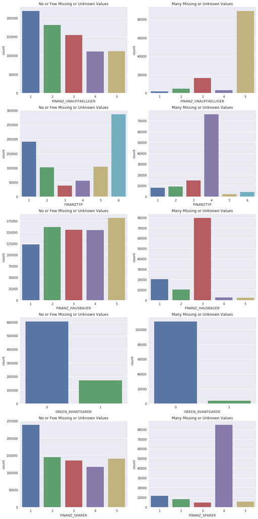

```python
# Set figure size and subplot space adjustments
sns.set(rc={'figure.figsize':(12,12)})
plt.subplots_adjust(left=0.1, bottom=0.1, right=1.0, top=2.0, wspace=0.2, hspace=0.2)

# Iterate through attributes to be plotted
for idx in range( len(plotted_attributes) ):
    # Plot subplot 1
    plt.subplot(len(plotted_attributes), 2, 2*idx+1)
    sns.countplot( azdias_lessthan_threshold[ plotted_attributes['attributes'][idx] ] )
    plt.title('No or Few Missing or Unknown Values')
    # Plot subplot 1
    plt.subplot(len(plotted_attributes), 2, 2*idx+2)
    sns.countplot( azdias_morethan_threshold[ plotted_attributes['attributes'][idx] ] )
    plt.title('Many Missing or Unknown Values')
```

```python
azdias.shape
```

```
(891221, 81)
```

```python
# Set the number of missing or unknown values per row
drop_threshold = 10

# Get subset with rows having missing or unknown values equal or below the drop threshold
azdias = azdias[ azdias.isnull().sum(axis = 1) <= drop_threshold ]
```

```python
azdias.shape
```

```
(776422, 81)
```

#### Discussion 1.1.3: Assess Missing Data in Each Row

In general, the data from rows with no or few missing values have a more balanced distribution across the variables than data from rows with lots of missing values, some more pronounced than others. In general , in the data from rows with lots of missing values, there is usually a value that dominates the distribution. This may be an issue when applying the model and result in wrong conclusions. Therefore, these rwos with too many missing or unknown values need to be dropped.

From the evaluation above, I observed that the majority of rows have 0, 1 or 2 missing or unknown values (see histogram above), which is great over 85 attributes. A minority has between 4 to 10 missing or unknown values (see histogram above), which is OK.

I concluded that dropping rows with more than 10 missing or unknown values per row may be a conservative choice, but the 114'799 rows with more than 10 missing or unknown values that will be dropped stand in a reasonable proportion to the 348'158 rows without a missing or unknown value. Playing with the drop_threshold of 3 and 10 indicates, that the distributions of the above graphs does not change significantly in nature. Therfore, I stay with my decision to drop rows with more than 10 missing or unknown values per row.

### Step 1.2: Select and Re-Encode Features

Checking for missing data isn't the only way in which you can prepare a dataset for analysis. Since the unsupervised learning techniques to be used will only work on data that is encoded numerically, you need to make a few encoding changes or additional assumptions to be able to make progress. In addition, while almost all of the values in the dataset are encoded using numbers, not all of them represent numeric values. Check the third column of the feature summary (`feat_info`) for a summary of types of measurement.

- For numeric and interval data, these features can be kept without changes.
- Most of the variables in the dataset are ordinal in nature. While ordinal values may technically be non-linear in spacing, make the simplifying assumption that the ordinal variables can be treated as being interval in nature (that is, kept without any changes).
- Special handling may be necessary for the remaining two variable types: categorical, and 'mixed'.

In the first two parts of this sub-step, you will perform an investigation of the categorical and mixed-type features and make a decision on each of them, whether you will keep, drop, or re-encode each. Then, in the last part, you will create a new data frame with only the selected and engineered columns.

Data wrangling is often the trickiest part of the data analysis process, and there's a lot of it to be done here. But stick with it: once you're done with this step, you'll be ready to get to the machine learning parts of the project!

```python
# How many features are there of each data type?
feat_info['type'].value_counts()
```

```
ordinal        49
categorical    21
numeric         7
mixed           7
interval        1
Name: type, dtype: int64
```

#### Step 1.2.1: Re-Encode Categorical Features

For categorical data, you would ordinarily need to encode the levels as dummy variables. Depending on the number of categories, perform one of the following:

- For binary (two-level) categoricals that take numeric values, you can keep them without needing to do anything.
- There is one binary variable that takes on non-numeric values. For this one, you need to re-encode the values as numbers or create a dummy variable.
- For multi-level categoricals (three or more values), you can choose to encode the values using multiple dummy variables (e.g. via [OneHotEncoder](http://scikit-learn.org/stable/modules/generated/sklearn.preprocessing.OneHotEncoder.html)), or (to keep things straightforward) just drop them from the analysis. As always, document your choices in the Discussion section.

```python
# Assess categorical variables: which are binary, which are multi-level, and
# which one needs to be re-encoded?

# List all categorical variables in feat_info
categorical_attributes = feat_info[ feat_info['type'] == 'categorical' ]['attribute'].to_frame()

# List all variables in azdias
azdias_attributes = azdias.columns.to_frame().rename(columns={0: "attribute"})

# find attributes that are both in categorical_attributes and azdias
merged_cat_attributes = categorical_attributes.merge(azdias_attributes,left_on='attribute',right_on='attribute',how='inner')

# Empty lists for binary and multi level features
binary_features = []
multi_features = []

# Iterate through the attributes in merged_attributes and append attribute to binary or multi level features
for attribute in merged_cat_attributes.attribute:
    if len( azdias[attribute].value_counts() ) == 2:
        binary_features.append(attribute)
    elif len( azdias[attribute].value_counts() ) > 2:
        multi_features.append(attribute)
```

```python
# Print unique values of binary features
for attribute in binary_features:
    print('Featrure {} contains unique values {}'.format(attribute, azdias[attribute].unique()) )
```

```
Featrure ANREDE_KZ contains unique values [2 1]
Featrure GREEN_AVANTGARDE contains unique values [0 1]
Featrure SOHO_KZ contains unique values [ 1.  0.]
Featrure VERS_TYP contains unique values [  2.   1.  nan]
Featrure OST_WEST_KZ contains unique values ['W' 'O']
```

```python
# Print unique values of multi level features
for attribute in multi_features:
    print('Featrure {} is a multi level feature'.format(attribute) )
```

```
Featrure CJT_GESAMTTYP is a multi level feature
Featrure FINANZTYP is a multi level feature
Featrure GFK_URLAUBERTYP is a multi level feature
Featrure LP_FAMILIE_FEIN is a multi level feature
Featrure LP_FAMILIE_GROB is a multi level feature
Featrure LP_STATUS_FEIN is a multi level feature
Featrure LP_STATUS_GROB is a multi level feature
Featrure NATIONALITAET_KZ is a multi level feature
Featrure SHOPPER_TYP is a multi level feature
Featrure ZABEOTYP is a multi level feature
Featrure GEBAEUDETYP is a multi level feature
Featrure CAMEO_DEUG_2015 is a multi level feature
Featrure CAMEO_DEU_2015 is a multi level feature
```

```python
# Sanity check
azdias['OST_WEST_KZ'].unique()
```

```
array(['W', 'O'], dtype=object)
```

```python
# Re-encode categorical variable(s) OST_WEST_KZ to be kept in the analysis.
azdias['OST_WEST_KZ'].replace({'W': 0, 'O': 1}, inplace = True)
```

```python
# Sanity check
azdias['OST_WEST_KZ'].unique()
```

```
array([0, 1])
```

```python
# Drop columns with multi level features
azdias.drop(columns = multi_features, inplace = True)
```

#### Discussion 1.2.1: Re-Encode Categorical Features

- The 4 binary categorical features with numeric values are kept without modification.
- The 1 binary categorical feature OST_WEST_KZ with non-numeric values is re-encoded.
- The 13 multi-level categorical features are drop from the analysis.

#### Step 1.2.2: Engineer Mixed-Type Features

There are a handful of features that are marked as "mixed" in the feature summary that require special treatment in order to be included in the analysis. There are two in particular that deserve attention; the handling of the rest are up to your own choices:

- "PRAEGENDE_JUGENDJAHRE" combines information on three dimensions: generation by decade, movement (mainstream vs. avantgarde), and nation (east vs. west). While there aren't enough levels to disentangle east from west, you should create two new variables to capture the other two dimensions: an interval-type variable for decade, and a binary variable for movement.
- "CAMEO_INTL_2015" combines information on two axes: wealth and life stage. Break up the two-digit codes by their 'tens'-place and 'ones'-place digits into two new ordinal variables (which, for the purposes of this project, is equivalent to just treating them as their raw numeric values).
- If you decide to keep or engineer new features around the other mixed-type features, make sure you note your steps in the Discussion section.

Be sure to check `Data_Dictionary.md` for the details needed to finish these tasks.

```python
# Assess mixed variables

# List all mixed variables in feat_info
mixed_attributes = feat_info[ feat_info['type'] == 'mixed' ]['attribute'].to_frame()

# # List all variables in azdias
azdias_attributes = azdias.columns.to_frame().rename(columns={0: "attribute"})

# find attributes that are both in categorical_attributes and azdias
merged_mixed_attributes = mixed_attributes.merge(azdias_attributes,left_on='attribute',right_on='attribute',how='inner')

# Display merged_mixed_attributes
merged_mixed_attributes
```

|  | attribute |
| --- | --- |
| 0 | LP_LEBENSPHASE_FEIN |
| 1 | LP_LEBENSPHASE_GROB |
| 2 | PRAEGENDE_JUGENDJAHRE |
| 3 | WOHNLAGE |
| 4 | CAMEO_INTL_2015 |
| 5 | PLZ8_BAUMAX |

**Investigate PRAEGENDE_JUGENDJAHRE**

Look at original data.

**PRAEGENDE_JUGENDJAHRE** Dominating movement of person's youth (avantgarde vs. mainstream; east vs. west)

- -1: unknown
- 0: unknown
- 1: 40s - war years (Mainstream, E+W)
- 2: 40s - reconstruction years (Avantgarde, E+W)
- 3: 50s - economic miracle (Mainstream, E+W)
- 4: 50s - milk bar / Individualisation (Avantgarde, E+W)
- 5: 60s - economic miracle (Mainstream, E+W)
- 6: 60s - generation 68 / student protestors (Avantgarde, W)
- 7: 60s - opponents to the building of the Wall (Avantgarde, E)
- 8: 70s - family orientation (Mainstream, E+W)
- 9: 70s - peace movement (Avantgarde, E+W)
- 10: 80s - Generation Golf (Mainstream, W)
- 11: 80s - ecological awareness (Avantgarde, W)
- 12: 80s - FDJ / communist party youth organisation (Mainstream, E)
- 13: 80s - Swords into ploughshares (Avantgarde, E)
- 14: 90s - digital media kids (Mainstream, E+W)
- 15: 90s - ecological awareness (Avantgarde, E+W)

Information of original data is replaced by following two columns.

**PJ_DECADE** Dominating movement decade

- 1: 40s
- 2: 50s
- 3: 60s
- 4: 70s
- 5: 80s
- 6: 90s

**PJ_MOVEMENT** Dominating movement

- 1: Mainstream
- 2: Avantgarde

```python
# Look at data
azdias.PRAEGENDE_JUGENDJAHRE.value_counts()
```

```
14.0    178178
8.0     138220
10.0     83704
5.0      83357
3.0      52931
15.0     40957
11.0     34574
9.0      33105
6.0      25418
12.0     23980
4.0      20277
1.0      20170
2.0       7410
13.0      5544
7.0       3949
Name: PRAEGENDE_JUGENDJAHRE, dtype: int64
```

```python
# Investigate "PRAEGENDE_JUGENDJAHRE" and engineer two new variables.

# Append a column PJ_DECADE which will contain the decade information of PRAEGENDE_JUGENDJAHRE
azdias['PJ_DECADE'] = azdias['PRAEGENDE_JUGENDJAHRE']

# Create the dictionary to replace the values in PJ_DECADE
pj_decade_dict = {1:1, 2:1, 3:2, 4:2, 5:3, 6:3, 7:3, 8:4, 9:4, 10:5, 11:5, 12:5, 13:5, 14:6, 15:6}

# Replace the values in PJ_DECADE
azdias.PJ_DECADE.replace(pj_decade_dict, inplace = True)
```

```python
# Append a column PJ_MOVEMENT which will contain the movement information of PRAEGENDE_JUGENDJAHRE
azdias['PJ_MOVEMENT'] = azdias['PRAEGENDE_JUGENDJAHRE']

# Create the dictionary to replace the values in PJ_DECADE
pj_movement_dict = {1:1, 2:2, 3:1, 4:2, 5:1, 6:2, 7:2, 8:1, 9:2, 10:1, 11:2, 12:1, 13:2, 14:1, 15:2}

# Replace the values in PJ_DECADE
azdias.PJ_MOVEMENT.replace(pj_movement_dict, inplace = True)
```

```python
# Sanity check
azdias.PJ_DECADE.value_counts()
```

```
6.0    219135
4.0    171325
5.0    147802
3.0    112724
2.0     73208
1.0     27580
Name: PJ_DECADE, dtype: int64
```

```python
# Sanity check
azdias.PJ_MOVEMENT.value_counts()
```

```
1.0    580540
2.0    171234
Name: PJ_MOVEMENT, dtype: int64
```

```python
# Drop PRAEGENDE_JUGENDJAHRE
azdias.drop(columns = ['PRAEGENDE_JUGENDJAHRE'], inplace = True)
```

**Investigate CAMEO_INTL_2015**

Look at original data.

**CAMEO_INTL_2015** German CAMEO: Wealth / Life Stage Typology, mapped to international code

- -1: unknown
- 11: Wealthy Households - Pre-Family Couples & Singles
- 12: Wealthy Households - Young Couples With Children
- 13: Wealthy Households - Families With School Age Children
- 14: Wealthy Households - Older Families & Mature Couples
- 15: Wealthy Households - Elders In Retirement
- 21: Prosperous Households - Pre-Family Couples & Singles
- 22: Prosperous Households - Young Couples With Children
- 23: Prosperous Households - Families With School Age Children
- 24: Prosperous Households - Older Families & Mature Couples
- 25: Prosperous Households - Elders In Retirement
- 31: Comfortable Households - Pre-Family Couples & Singles
- 32: Comfortable Households - Young Couples With Children
- 33: Comfortable Households - Families With School Age Children
- 34: Comfortable Households - Older Families & Mature Couples
- 35: Comfortable Households - Elders In Retirement
- 41: Less Affluent Households - Pre-Family Couples & Singles
- 42: Less Affluent Households - Young Couples With Children
- 43: Less Affluent Households - Families With School Age Children
- 44: Less Affluent Households - Older Families & Mature Couples
- 45: Less Affluent Households - Elders In Retirement
- 51: Poorer Households - Pre-Family Couples & Singles
- 52: Poorer Households - Young Couples With Children
- 53: Poorer Households - Families With School Age Children
- 54: Poorer Households - Older Families & Mature Couples
- 55: Poorer Households - Elders In Retirement
- XX: unknown

Information of original data is replaced by following two columns.

**CAMEO_WEALTH** German CAMEO: Wealth Typology

- 1: Wealthy Households
- 2: Prosperous Households
- 3: Comfortable Households
- 4: Less Affluent Households
- 5: Poorer Households

**CAMEO_STAGE** German CAMEO: Life Stage Typology

- 1: Pre-Family Couples & Singles
- 2: Young Couples With Children
- 3: Families With School Age Children
- 4: Older Families & Mature Couples
- 5: Elders In Retirement

```python
# Look at data
azdias.CAMEO_INTL_2015.value_counts()
```

```
51    132421
41     90669
24     88841
14     61163
43     55602
54     44792
25     38663
22     32068
45     25657
13     25532
23     24132
55     23368
52     20288
34     18162
31     17728
15     16684
44     14525
12     12797
35     10155
32     10118
33      9583
Name: CAMEO_INTL_2015, dtype: int64
```

```python
# Investigate "CAMEO_INTL_2015" and engineer two new variables.

# Append a column CAMEO_WEALTH which will contain the wealth information of CAMEO_INTL_2015
azdias['CAMEO_WEALTH'] = azdias['CAMEO_INTL_2015']

# Create the dictionary to replace the values in CAMEO_WEALTH
cameo_wealth_dict = {'11':1, '12':1, '13':1, '14':1, '15':1, '21':2, '22':2, '23':2, '24':2, '25':2, '31':3, '32':3, '33':3, '34':3, '35':3, '41':4, '42':4, '43':4, '44':4, '45':4, '51':5, '52':5, '53':5, '54':5, '55':5}

# Replace the values in CAMEO_WEALTH
azdias['CAMEO_WEALTH'].replace(cameo_wealth_dict, inplace = True)
```

```python
# Append a column CAMEO_STAGE which will contain the stage of life information of CAMEO_INTL_2015
azdias['CAMEO_STAGE'] = azdias['CAMEO_INTL_2015']

# Create the dictionary to replace the values in CAMEO_STAGE
cameo_stage_dict = {'11':1, '12':2, '13':3, '14':4, '15':5, '21':1, '22':2, '23':3, '24':4, '25':5, '31':1, '32':2, '33':3, '34':4, '35':5, '41':1, '42':2, '43':3, '44':4, '45':5, '51':1, '52':2, '53':3, '54':4, '55':5}

# Replace the values in CAMEO_WEALTH
azdias['CAMEO_STAGE'].replace(cameo_stage_dict, inplace = True)
```

```python
# Sanity check
azdias.CAMEO_WEALTH.value_counts()
```

```
5.0    220869
4.0    186453
2.0    183704
1.0    116176
3.0     65746
Name: CAMEO_WEALTH, dtype: int64
```

```python
# Sanity check
azdias.CAMEO_STAGE.value_counts()
```

```
1.0    240818
4.0    227483
3.0    114849
5.0    114527
2.0     75271
Name: CAMEO_STAGE, dtype: int64
```

```python
# Drop CAMEO_INTL_2015
azdias.drop(columns = ['CAMEO_INTL_2015'], inplace = True)
```

```python
# Drop the remaining mixed features from the dataset,
azdias.drop(columns = ['LP_LEBENSPHASE_FEIN', 'LP_LEBENSPHASE_GROB', 'WOHNLAGE', 'PLZ8_BAUMAX'], inplace = True)
```

```python
# Look at the dataframe with dropped attributes
azdias.head()
```

|  | ALTERSKATEGORIE_GROB | ANREDE_KZ | FINANZ_MINIMALIST | FINANZ_SPARER | FINANZ_VORSORGER | FINANZ_ANLEGER | FINANZ_UNAUFFAELLIGER | FINANZ_HAUSBAUER | GEBURTSJAHR | GREEN_AVANTGARDE | ... | PLZ8_ANTG4 | PLZ8_HHZ | PLZ8_GBZ | ARBEIT | ORTSGR_KLS9 | RELAT_AB | PJ_DECADE | PJ_MOVEMENT | CAMEO_WEALTH | CAMEO_STAGE |
| --- | --- | --- | --- | --- | --- | --- | --- | --- | --- | --- | --- | --- | --- | --- | --- | --- | --- | --- | --- | --- | --- |
| 1 | 1.0 | 2 | 1 | 5 | 2 | 5 | 4 | 5 | 1996.0 | 0 | ... | 1.0 | 5.0 | 4.0 | 3.0 | 5.0 | 4.0 | 6.0 | 1.0 | 5.0 | 1.0 |
| 2 | 3.0 | 2 | 1 | 4 | 1 | 2 | 3 | 5 | 1979.0 | 1 | ... | 0.0 | 4.0 | 4.0 | 3.0 | 5.0 | 2.0 | 6.0 | 2.0 | 2.0 | 4.0 |
| 3 | 4.0 | 2 | 4 | 2 | 5 | 2 | 1 | 2 | 1957.0 | 0 | ... | 0.0 | 3.0 | 4.0 | 2.0 | 3.0 | 3.0 | 4.0 | 1.0 | 1.0 | 2.0 |
| 4 | 3.0 | 1 | 4 | 3 | 4 | 1 | 3 | 2 | 1963.0 | 0 | ... | 1.0 | 3.0 | 3.0 | 4.0 | 6.0 | 5.0 | 4.0 | 1.0 | 4.0 | 3.0 |
| 5 | 1.0 | 2 | 3 | 1 | 5 | 2 | 2 | 5 | 1943.0 | 0 | ... | 1.0 | 5.0 | 5.0 | 2.0 | 3.0 | 3.0 | 2.0 | 1.0 | 5.0 | 4.0 |

5 rows × 66 columns

#### Discussion 1.2.2: Engineer Mixed-Type Features

The mixed featured are treated as follwing.

- PRAEGENDE_JUGENDJAHRE is separated into two dimensions. PJ_DECADE containing the dominating movement decade as well as PJ_MOVEMENT containing the dominating movement. PRAEGENDE_JUGENDJAHRE is dropped.
- CAMEO_INTL_2015 is separated into two dimensions. CAMEO_WEALTH containing the wealth typology as well as CAMEO_STAGE containing the life stage typology. CAMEO_INTL_2015 is dropped.
- LP_LEBENSPHASE_FEIN and LP_LEBENSPHASE_GROB are dropped as it seems to be difficult to unbundle the information in two or three meaningful columns.
- WOHNLAGE is dropped as the last two categiries 7, 8 do not extend well with the previous categories. However, it does not seem to be obvious why this feature is mixed and not categorical.
- PLZ8_BAUMAX is dropped as there is a lot of other information on the distribution of family homes in the dataset. However, it does not seem to be obvious why this feature is mixed and not categorical.

#### Step 1.2.3: Complete Feature Selection

In order to finish this step up, you need to make sure that your data frame now only has the columns that you want to keep. To summarize, the dataframe should consist of the following:

- All numeric, interval, and ordinal type columns from the original dataset.
- Binary categorical features (all numerically-encoded).
- Engineered features from other multi-level categorical features and mixed features.

Make sure that for any new columns that you have engineered, that you've excluded the original columns from the final dataset. Otherwise, their values will interfere with the analysis later on the project. For example, you should not keep "PRAEGENDE_JUGENDJAHRE", since its values won't be useful for the algorithm: only the values derived from it in the engineered features you created should be retained. As a reminder, your data should only be from **the subset with few or no missing values**.

```python
# If there are other re-engineering tasks you need to perform, make sure you
# take care of them here. (Dealing with missing data will come in step 2.1.)

# all set

azdias.head()
```

|  | ALTERSKATEGORIE_GROB | ANREDE_KZ | FINANZ_MINIMALIST | FINANZ_SPARER | FINANZ_VORSORGER | FINANZ_ANLEGER | FINANZ_UNAUFFAELLIGER | FINANZ_HAUSBAUER | GEBURTSJAHR | GREEN_AVANTGARDE | ... | PLZ8_ANTG4 | PLZ8_HHZ | PLZ8_GBZ | ARBEIT | ORTSGR_KLS9 | RELAT_AB | PJ_DECADE | PJ_MOVEMENT | CAMEO_WEALTH | CAMEO_STAGE |
| --- | --- | --- | --- | --- | --- | --- | --- | --- | --- | --- | --- | --- | --- | --- | --- | --- | --- | --- | --- | --- | --- |
| 1 | 1.0 | 2 | 1 | 5 | 2 | 5 | 4 | 5 | 1996.0 | 0 | ... | 1.0 | 5.0 | 4.0 | 3.0 | 5.0 | 4.0 | 6.0 | 1.0 | 5.0 | 1.0 |
| 2 | 3.0 | 2 | 1 | 4 | 1 | 2 | 3 | 5 | 1979.0 | 1 | ... | 0.0 | 4.0 | 4.0 | 3.0 | 5.0 | 2.0 | 6.0 | 2.0 | 2.0 | 4.0 |
| 3 | 4.0 | 2 | 4 | 2 | 5 | 2 | 1 | 2 | 1957.0 | 0 | ... | 0.0 | 3.0 | 4.0 | 2.0 | 3.0 | 3.0 | 4.0 | 1.0 | 1.0 | 2.0 |
| 4 | 3.0 | 1 | 4 | 3 | 4 | 1 | 3 | 2 | 1963.0 | 0 | ... | 1.0 | 3.0 | 3.0 | 4.0 | 6.0 | 5.0 | 4.0 | 1.0 | 4.0 | 3.0 |
| 5 | 1.0 | 2 | 3 | 1 | 5 | 2 | 2 | 5 | 1943.0 | 0 | ... | 1.0 | 5.0 | 5.0 | 2.0 | 3.0 | 3.0 | 2.0 | 1.0 | 5.0 | 4.0 |

5 rows × 66 columns

```python
# Do whatever you need to in order to ensure that the dataframe only contains
# the columns that should be passed to the algorithm functions.

# all set

# List all variables in azdias
azdias_attributes = azdias.columns.to_frame().rename(columns={0: "attribute"})

azdias_attributes
```

|  | attribute |
| --- | --- |
| ALTERSKATEGORIE_GROB | ALTERSKATEGORIE_GROB |
| ANREDE_KZ | ANREDE_KZ |
| FINANZ_MINIMALIST | FINANZ_MINIMALIST |
| FINANZ_SPARER | FINANZ_SPARER |
| FINANZ_VORSORGER | FINANZ_VORSORGER |
| FINANZ_ANLEGER | FINANZ_ANLEGER |
| FINANZ_UNAUFFAELLIGER | FINANZ_UNAUFFAELLIGER |
| FINANZ_HAUSBAUER | FINANZ_HAUSBAUER |
| GEBURTSJAHR | GEBURTSJAHR |
| GREEN_AVANTGARDE | GREEN_AVANTGARDE |
| HEALTH_TYP | HEALTH_TYP |
| RETOURTYP_BK_S | RETOURTYP_BK_S |
| SEMIO_SOZ | SEMIO_SOZ |
| SEMIO_FAM | SEMIO_FAM |
| SEMIO_REL | SEMIO_REL |
| SEMIO_MAT | SEMIO_MAT |
| SEMIO_VERT | SEMIO_VERT |
| SEMIO_LUST | SEMIO_LUST |
| SEMIO_ERL | SEMIO_ERL |
| SEMIO_KULT | SEMIO_KULT |
| SEMIO_RAT | SEMIO_RAT |
| SEMIO_KRIT | SEMIO_KRIT |
| SEMIO_DOM | SEMIO_DOM |
| SEMIO_KAEM | SEMIO_KAEM |
| SEMIO_PFLICHT | SEMIO_PFLICHT |
| SEMIO_TRADV | SEMIO_TRADV |
| SOHO_KZ | SOHO_KZ |
| VERS_TYP | VERS_TYP |
| ALTER_HH | ALTER_HH |
| ANZ_PERSONEN | ANZ_PERSONEN |
| ... | ... |
| KONSUMNAEHE | KONSUMNAEHE |
| MIN_GEBAEUDEJAHR | MIN_GEBAEUDEJAHR |
| OST_WEST_KZ | OST_WEST_KZ |
| KBA05_ANTG1 | KBA05_ANTG1 |
| KBA05_ANTG2 | KBA05_ANTG2 |
| KBA05_ANTG3 | KBA05_ANTG3 |
| KBA05_ANTG4 | KBA05_ANTG4 |
| KBA05_GBZ | KBA05_GBZ |
| BALLRAUM | BALLRAUM |
| EWDICHTE | EWDICHTE |
| INNENSTADT | INNENSTADT |
| GEBAEUDETYP_RASTER | GEBAEUDETYP_RASTER |
| KKK | KKK |
| MOBI_REGIO | MOBI_REGIO |
| ONLINE_AFFINITAET | ONLINE_AFFINITAET |
| REGIOTYP | REGIOTYP |
| KBA13_ANZAHL_PKW | KBA13_ANZAHL_PKW |
| PLZ8_ANTG1 | PLZ8_ANTG1 |
| PLZ8_ANTG2 | PLZ8_ANTG2 |
| PLZ8_ANTG3 | PLZ8_ANTG3 |
| PLZ8_ANTG4 | PLZ8_ANTG4 |
| PLZ8_HHZ | PLZ8_HHZ |
| PLZ8_GBZ | PLZ8_GBZ |
| ARBEIT | ARBEIT |
| ORTSGR_KLS9 | ORTSGR_KLS9 |
| RELAT_AB | RELAT_AB |
| PJ_DECADE | PJ_DECADE |
| PJ_MOVEMENT | PJ_MOVEMENT |
| CAMEO_WEALTH | CAMEO_WEALTH |
| CAMEO_STAGE | CAMEO_STAGE |

66 rows × 1 columns

### Step 1.3: Create a Cleaning Function

Even though you've finished cleaning up the general population demographics data, it's important to look ahead to the future and realize that you'll need to perform the same cleaning steps on the customer demographics data. In this substep, complete the function below to execute the main feature selection, encoding, and re-engineering steps you performed above. Then, when it comes to looking at the customer data in Step 3, you can just run this function on that DataFrame to get the trimmed dataset in a single step.

```python
def clean_data(df, feat_info):
    """
    Perform feature trimming, re-encoding, and engineering for demographics
    data

    INPUT: Demographics DataFrame
    OUTPUT: Trimmed and cleaned demographics DataFrame
    """
    # Step 1.1.1
    # Convert missing value codes into NaNs, ...
    # Identify missing or unknown data values and convert them to NaNs.
    for idx in range(feat_info.shape[0]): # Iterate through feat_info
        attribute = feat_info['attribute'][idx] # Assign attribute of current iteration to variable
        elements = feat_info['missing_or_unknown'][idx] # Assign elements of current iteration to variable (type: str)
        elements = elements.strip('[').strip(']').split(',') # Strip brackets and split string (type: list)
        elements = [int(indicator) if indicator.isdigit() else indicator for indicator in elements] # Convert non-negative numbers into int
        elements = [-1 if indicator == '-1' else indicator for indicator in elements] # Set '-1' to -1
        elements = [ None if indicator == '' else indicator for indicator in elements] # Set None for an empty list

        for indicator in elements:
            replace_dict = {attribute: indicator}
            df.replace(replace_dict, np.nan, inplace=True) # Set value to NaN

    # Step 1.1.2
    # Remove the outlier columns from the dataset
    df.drop(columns = ['TITEL_KZ', 'AGER_TYP', 'KK_KUNDENTYP', 'KBA05_BAUMAX'], inplace = True)

    # Step 1.1.3
    # Remove the outlier rows from the dataset.
    # Set the number of missing or unknown values per row
    drop_threshold = 10

    # Get subset with rows having missing or unknown values equal or below the drop threshold
    df = df[ df.isnull().sum(axis = 1) <= drop_threshold ]

    # Step 1.2.1
    # Re-encode ot drop categorical features
    # Re-encode categorical variable OST_WEST_KZ to be kept in the analysis.
    df['OST_WEST_KZ'].replace({'W': 0, 'O': 1}, inplace = True)

    # Drop columns with multi level features
    df.drop(columns = ['CJT_GESAMTTYP', 'FINANZTYP', 'GFK_URLAUBERTYP', 'LP_FAMILIE_FEIN', 'LP_FAMILIE_GROB', 'LP_STATUS_FEIN', 'LP_STATUS_GROB', 'NATIONALITAET_KZ', 'SHOPPER_TYP', 'ZABEOTYP', 'GEBAEUDETYP', 'CAMEO_DEUG_2015', 'CAMEO_DEU_2015'], inplace = True)

    # Step 1.2.2
    # Re-encode or drop mixed features
    # Append a column PJ_DECADE which will contain the decade information of PRAEGENDE_JUGENDJAHRE
    df['PJ_DECADE'] = df['PRAEGENDE_JUGENDJAHRE']
    # Create the dictionary to replace the values in PJ_DECADE
    pj_decade_dict = {1:1, 2:1, 3:2, 4:2, 5:3, 6:3, 7:3, 8:4, 9:4, 10:5, 11:5, 12:5, 13:5, 14:6, 15:6}
    # Replace the values in PJ_DECADE
    df.PJ_DECADE.replace(pj_decade_dict, inplace = True)

    # Append a column PJ_MOVEMENT which will contain the movement information of PRAEGENDE_JUGENDJAHRE
    df['PJ_MOVEMENT'] = df['PRAEGENDE_JUGENDJAHRE']
    # Create the dictionary to replace the values in PJ_DECADE
    pj_movement_dict = {1:1, 2:2, 3:1, 4:2, 5:1, 6:2, 7:2, 8:1, 9:2, 10:1, 11:2, 12:1, 13:2, 14:1, 15:2}
    # Replace the values in PJ_DECADE
    df.PJ_MOVEMENT.replace(pj_movement_dict, inplace = True)

    # Append a column CAMEO_WEALTH which will contain the wealth information of CAMEO_INTL_2015
    df['CAMEO_WEALTH'] = df['CAMEO_INTL_2015']
    # Create the dictionary to replace the values in CAMEO_WEALTH
    cameo_wealth_dict = {'11':1, '12':1, '13':1, '14':1, '15':1, '21':2, '22':2, '23':2, '24':2, '25':2, '31':3, '32':3, '33':3, '34':3, '35':3, '41':4, '42':4, '43':4, '44':4, '45':4, '51':5, '52':5, '53':5, '54':5, '55':5}
    # Replace the values in CAMEO_WEALTH
    df['CAMEO_WEALTH'].replace(cameo_wealth_dict, inplace = True)

    # Append a column CAMEO_STAGE which will contain the stage of life information of CAMEO_INTL_2015
    df['CAMEO_STAGE'] = df['CAMEO_INTL_2015']
    # Create the dictionary to replace the values in CAMEO_STAGE
    cameo_stage_dict = {'11':1, '12':2, '13':3, '14':4, '15':5, '21':1, '22':2, '23':3, '24':4, '25':5, '31':1, '32':2, '33':3, '34':4, '35':5, '41':1, '42':2, '43':3, '44':4, '45':5, '51':1, '52':2, '53':3, '54':4, '55':5}
    # Replace the values in CAMEO_WEALTH
    df['CAMEO_STAGE'].replace(cameo_stage_dict, inplace = True)

    # Drop unnecessary mixed features from the dataset
    df.drop(columns = ['PRAEGENDE_JUGENDJAHRE', 'CAMEO_INTL_2015', 'LP_LEBENSPHASE_FEIN', 'LP_LEBENSPHASE_GROB', 'WOHNLAGE', 'PLZ8_BAUMAX'], inplace = True)

    # Return the cleaned dataframe.
    return df
```

```python
# Test function clean_data()
azdias_clean = clean_data(azdias_original_df, feat_info)
```

```python
azdias_clean.head()
```

|  | ALTERSKATEGORIE_GROB | ANREDE_KZ | FINANZ_MINIMALIST | FINANZ_SPARER | FINANZ_VORSORGER | FINANZ_ANLEGER | FINANZ_UNAUFFAELLIGER | FINANZ_HAUSBAUER | GEBURTSJAHR | GREEN_AVANTGARDE | ... | PLZ8_ANTG4 | PLZ8_HHZ | PLZ8_GBZ | ARBEIT | ORTSGR_KLS9 | RELAT_AB | PJ_DECADE | PJ_MOVEMENT | CAMEO_WEALTH | CAMEO_STAGE |
| --- | --- | --- | --- | --- | --- | --- | --- | --- | --- | --- | --- | --- | --- | --- | --- | --- | --- | --- | --- | --- | --- |
| 1 | 1.0 | 2 | 1 | 5 | 2 | 5 | 4 | 5 | 1996.0 | 0 | ... | 1.0 | 5.0 | 4.0 | 3.0 | 5.0 | 4.0 | 6.0 | 1.0 | 5.0 | 1.0 |
| 2 | 3.0 | 2 | 1 | 4 | 1 | 2 | 3 | 5 | 1979.0 | 1 | ... | 0.0 | 4.0 | 4.0 | 3.0 | 5.0 | 2.0 | 6.0 | 2.0 | 2.0 | 4.0 |
| 3 | 4.0 | 2 | 4 | 2 | 5 | 2 | 1 | 2 | 1957.0 | 0 | ... | 0.0 | 3.0 | 4.0 | 2.0 | 3.0 | 3.0 | 4.0 | 1.0 | 1.0 | 2.0 |
| 4 | 3.0 | 1 | 4 | 3 | 4 | 1 | 3 | 2 | 1963.0 | 0 | ... | 1.0 | 3.0 | 3.0 | 4.0 | 6.0 | 5.0 | 4.0 | 1.0 | 4.0 | 3.0 |
| 5 | 1.0 | 2 | 3 | 1 | 5 | 2 | 2 | 5 | 1943.0 | 0 | ... | 1.0 | 5.0 | 5.0 | 2.0 | 3.0 | 3.0 | 2.0 | 1.0 | 5.0 | 4.0 |

5 rows × 66 columns

## Step 2: Feature Transformation

### Step 2.1: Apply Feature Scaling

Before we apply dimensionality reduction techniques to the data, we need to perform feature scaling so that the principal component vectors are not influenced by the natural differences in scale for features. Starting from this part of the project, you'll want to keep an eye on the [API reference page for sklearn](http://scikit-learn.org/stable/modules/classes.html) to help you navigate to all of the classes and functions that you'll need. In this substep, you'll need to check the following:

- sklearn requires that data not have missing values in order for its estimators to work properly. So, before applying the scaler to your data, make sure that you've cleaned the DataFrame of the remaining missing values. This can be as simple as just removing all data points with missing data, or applying an [Imputer](http://scikit-learn.org/stable/modules/generated/sklearn.preprocessing.Imputer.html) to replace all missing values. You might also try a more complicated procedure where you temporarily remove missing values in order to compute the scaling parameters before re-introducing those missing values and applying imputation. Think about how much missing data you have and what possible effects each approach might have on your analysis, and justify your decision in the discussion section below.
- For the actual scaling function, a [StandardScaler](http://scikit-learn.org/stable/modules/generated/sklearn.preprocessing.StandardScaler.html) instance is suggested, scaling each feature to mean 0 and standard deviation 1.
- For these classes, you can make use of the `.fit_transform()` method to both fit a procedure to the data as well as apply the transformation to the data at the same time. Don't forget to keep the fit sklearn objects handy, since you'll be applying them to the customer demographics data towards the end of the project.

```python
# If you've not yet cleaned the dataset of all NaN values, then investigate and
# do that now.

# Instantiate imputer function as well as fit and transform data to imputer
imputer = Imputer(missing_values = 'NaN', strategy = 'mean', axis = 0)
azdias_imputed = imputer.fit_transform(azdias)
```

```python
# Apply feature scaling to the general population demographics data.

# Instatiate standard scaler as well as fit and transform data to standard scaler
standard_scaler = StandardScaler()
azdias_scaled = standard_scaler.fit_transform(azdias_imputed)
```

### Discussion 2.1: Apply Feature Scaling

- All occurrences of missing_values encoded as np.nan are replaced by the mean of the specific column.
- The data is standardize by removing the mean and scaling to unit variance using the StandardScaler method.

### Step 2.2: Perform Dimensionality Reduction

On your scaled data, you are now ready to apply dimensionality reduction techniques.

- Use sklearn's [PCA](http://scikit-learn.org/stable/modules/generated/sklearn.decomposition.PCA.html) class to apply principal component analysis on the data, thus finding the vectors of maximal variance in the data. To start, you should not set any parameters (so all components are computed) or set a number of components that is at least half the number of features (so there's enough features to see the general trend in variability).
- Check out the ratio of variance explained by each principal component as well as the cumulative variance explained. Try plotting the cumulative or sequential values using matplotlib's [`plot()`](https://matplotlib.org/api/_as_gen/matplotlib.pyplot.plot.html) function. Based on what you find, select a value for the number of transformed features you'll retain for the clustering part of the project.
- Once you've made a choice for the number of components to keep, make sure you re-fit a PCA instance to perform the decided-on transformation.

```python
# Apply PCA to the data.

# Instatiate principal component analysis as well as fit and transform data
pca = PCA(n_components = 50, random_state = 42)
azdias_pca = pca.fit_transform(azdias_scaled)
```

```python
# Investigate the variance accounted for by each principal component.

# Scree Plot as discussed in this classes section 4.4.13 Screencast: Interpretation of PCA Results
def scree_plot(pca):
    '''
    Creates a scree plot associated with the principal components
    INPUT: pca - the result of instantian of PCA in scikit learn
    OUTPUT: None
    '''
    num_components = len(pca.explained_variance_ratio_)
    ind = np.arange(num_components)
    vals = pca.explained_variance_ratio_

    plt.figure(figsize=(10, 6))
    ax = plt.subplot(111)
    cumvals = np.cumsum(vals)
    ax.bar(ind, vals)
    ax.plot(ind, cumvals)
    for i in range(num_components):
        ax.annotate(r"%s%%" % ((str(vals[i]*100)[:4])), (ind[i]+0.2, vals[i]), va="bottom", ha="center", fontsize=12)

    ax.xaxis.set_tick_params(width=0)
    ax.yaxis.set_tick_params(width=2, length=12)

    ax.set_xlabel("Principal Component")
    ax.set_ylabel("Variance Explained (%)")
    plt.title('Explained Variance Per Principal Component')
```

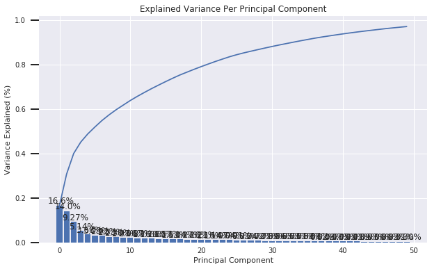

```python
# Create scree plot
scree_plot(pca)
```

```python
# Re-apply PCA to the data while selecting for number of components to retain.

# Instatiate principal component analysis as well as fit and transform data
pca = PCA(n_components = 33, random_state = 42)
azdias_pca = pca.fit_transform(azdias_scaled)
```

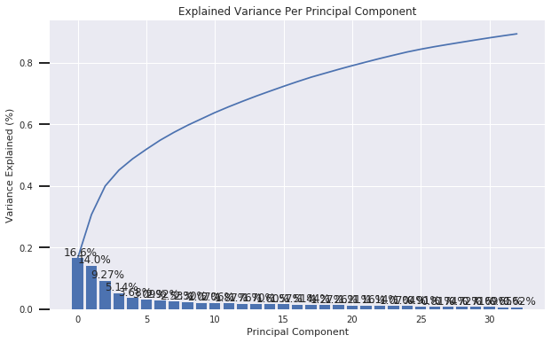

```python
# Create scree plot
scree_plot(pca)
```

```python
# Function discussed in this classes section 4.4.19 Notebook: PCA Mini-Project
def pca_results(full_dataset, pca):
    '''
    Create a DataFrame of the PCA results
    Includes dimension feature weights and explained variance
    Visualizes the PCA results
    '''
    # Dimension indexing
    dimensions = dimensions = ['Dimension {}'.format(i) for i in range(1,len(pca.components_)+1)]

    # PCA components
    components = pd.DataFrame(np.round(pca.components_, 4), columns = full_dataset.keys())
    components.index = dimensions

    # PCA explained variance
    ratios = pca.explained_variance_ratio_.reshape(len(pca.components_), 1)
    variance_ratios = pd.DataFrame(np.round(ratios, 4), columns = ['Explained Variance'])
    variance_ratios.index = dimensions

    # Create a bar plot visualization
    fig, ax = plt.subplots(figsize = (14,8))

    # Plot the feature weights as a function of the components
    components.plot(ax = ax, kind = 'bar');
    ax.set_ylabel("Feature Weights")
    ax.set_xticklabels(dimensions, rotation=0)

    # Display the explained variance ratios
    for i, ev in enumerate(pca.explained_variance_ratio_):
        ax.text(i-0.40, ax.get_ylim()[1] + 0.05, "Explained Variance\n %.4f"%(ev))

    # Return a concatenated DataFrame
    return pd.concat([variance_ratios, components], axis = 1)
```

|  | Explained Variance | ALTERSKATEGORIE_GROB | ANREDE_KZ | FINANZ_MINIMALIST | FINANZ_SPARER | FINANZ_VORSORGER | FINANZ_ANLEGER | FINANZ_UNAUFFAELLIGER | FINANZ_HAUSBAUER | GEBURTSJAHR | ... | PLZ8_ANTG4 | PLZ8_HHZ | PLZ8_GBZ | ARBEIT | ORTSGR_KLS9 | RELAT_AB | PJ_DECADE | PJ_MOVEMENT | CAMEO_WEALTH | CAMEO_STAGE |
| --- | --- | --- | --- | --- | --- | --- | --- | --- | --- | --- | --- | --- | --- | --- | --- | --- | --- | --- | --- | --- | --- |
| Dimension 1 | 0.1661 | -0.1466 | 0.0022 | -0.2265 | 0.1737 | -0.1413 | 0.0949 | 0.1020 | 0.1462 | 0.1098 | ... | 0.2057 | 0.0394 | -0.1567 | 0.1334 | 0.1838 | 0.1258 | 0.1335 | -0.1046 | 0.1952 | -0.1239 |
| Dimension 2 | 0.1408 | 0.2299 | 0.0669 | 0.0413 | -0.2119 | 0.2132 | -0.1973 | -0.2134 | 0.1347 | -0.1943 | ... | 0.1168 | 0.0182 | -0.0930 | 0.0854 | 0.1137 | 0.0810 | -0.2389 | -0.0286 | 0.1013 | -0.0157 |
| Dimension 3 | 0.0928 | 0.0499 | -0.3727 | 0.1449 | -0.0826 | 0.0783 | -0.1683 | -0.0778 | -0.0488 | -0.0717 | ... | 0.0400 | 0.0036 | -0.0338 | 0.0301 | 0.0398 | 0.0268 | -0.0870 | 0.0427 | 0.0241 | -0.0105 |
| Dimension 4 | 0.0514 | -0.0297 | 0.0315 | 0.0691 | -0.0081 | -0.0121 | -0.1298 | 0.0771 | -0.1080 | 0.0287 | ... | 0.0870 | 0.1384 | 0.0305 | 0.0545 | 0.2512 | 0.0973 | 0.0377 | 0.3985 | -0.1215 | 0.0565 |
| Dimension 5 | 0.0369 | 0.0224 | -0.0021 | 0.0882 | -0.0064 | -0.0586 | 0.0388 | -0.0506 | -0.0929 | 0.0341 | ... | 0.0213 | -0.4832 | -0.4009 | 0.2127 | 0.0890 | 0.1456 | 0.0373 | 0.0488 | -0.0015 | 0.0181 |
| Dimension 6 | 0.0309 | 0.0170 | 0.0087 | -0.0291 | 0.0108 | -0.0358 | 0.0268 | -0.0225 | 0.0239 | 0.0298 | ... | 0.0913 | -0.0162 | -0.0731 | -0.1748 | -0.0753 | -0.2093 | 0.0254 | 0.0078 | -0.0648 | 0.0470 |
| Dimension 7 | 0.0293 | 0.1416 | -0.0827 | 0.0126 | 0.0765 | -0.0374 | 0.0828 | 0.0575 | -0.1406 | 0.1794 | ... | 0.0545 | 0.2158 | 0.1216 | -0.0196 | 0.0416 | 0.0078 | 0.1423 | -0.0318 | 0.0582 | -0.0981 |
| Dimension 8 | 0.0254 | -0.1471 | 0.0116 | 0.1021 | -0.0712 | 0.1080 | -0.0650 | -0.0452 | -0.1112 | -0.1292 | ... | -0.0322 | 0.0741 | 0.0847 | 0.0228 | 0.1510 | 0.0410 | -0.0812 | -0.0324 | -0.0467 | 0.0072 |
| Dimension 9 | 0.0231 | 0.0102 | 0.0825 | 0.0713 | -0.1071 | 0.0553 | -0.0118 | -0.1366 | 0.0112 | -0.1355 | ... | 0.0790 | 0.1788 | 0.0723 | 0.1364 | 0.0170 | 0.0430 | -0.1062 | -0.0171 | 0.0393 | 0.0080 |
| Dimension 10 | 0.0208 | 0.1114 | 0.0391 | -0.1151 | 0.0839 | 0.0166 | 0.0192 | 0.2061 | 0.0714 | 0.0971 | ... | -0.0772 | -0.1712 | -0.0753 | -0.2479 | 0.0104 | -0.0752 | 0.0259 | 0.0880 | 0.0290 | -0.0948 |
| Dimension 11 | 0.0207 | -0.0515 | -0.0122 | 0.1107 | -0.1110 | 0.1726 | -0.1605 | -0.0886 | -0.1575 | -0.1177 | ... | 0.0106 | -0.1830 | -0.1468 | -0.3594 | -0.0920 | -0.1768 | -0.0563 | -0.1364 | 0.0491 | -0.1842 |
| Dimension 12 | 0.0188 | -0.0644 | 0.0101 | -0.0360 | -0.0161 | 0.0583 | 0.0396 | -0.0837 | 0.1350 | -0.0364 | ... | -0.0593 | 0.0217 | 0.0523 | 0.1654 | -0.0396 | 0.1926 | -0.0437 | 0.0538 | 0.0600 | 0.0921 |
| Dimension 13 | 0.0176 | 0.0756 | -0.0245 | 0.1651 | -0.0224 | -0.0940 | -0.0104 | 0.0130 | -0.2838 | 0.0127 | ... | 0.0779 | 0.0722 | -0.0197 | 0.0215 | -0.0281 | 0.0215 | 0.0405 | -0.1044 | 0.0735 | -0.2366 |
| Dimension 14 | 0.0170 | 0.0199 | -0.0230 | -0.0432 | 0.0044 | 0.0018 | -0.0502 | 0.0668 | -0.0417 | 0.0225 | ... | -0.1167 | -0.0717 | 0.0335 | -0.0608 | 0.1084 | -0.1245 | 0.0159 | -0.0776 | -0.1926 | 0.2682 |
| Dimension 15 | 0.0160 | -0.0090 | 0.0171 | 0.0189 | 0.0339 | -0.0043 | 0.0415 | 0.1129 | -0.1478 | -0.0206 | ... | 0.0468 | -0.0446 | -0.0459 | -0.0443 | -0.1027 | 0.1106 | 0.0240 | 0.3683 | 0.1156 | -0.1939 |
| Dimension 16 | 0.0157 | -0.0807 | 0.0406 | -0.0218 | 0.0072 | -0.0315 | 0.1404 | -0.0516 | 0.1483 | -0.0638 | ... | 0.1676 | 0.0184 | -0.1325 | -0.2771 | -0.0586 | -0.4994 | -0.0409 | 0.1310 | -0.0701 | 0.0585 |
| Dimension 17 | 0.0151 | -0.0024 | 0.0006 | 0.0052 | -0.0022 | -0.0008 | -0.0024 | 0.0055 | -0.0079 | -0.0038 | ... | 0.0102 | 0.0020 | -0.0056 | -0.0042 | -0.0038 | 0.0013 | -0.0001 | -0.0012 | -0.0015 | 0.0008 |
| Dimension 18 | 0.0144 | -0.0901 | 0.0358 | 0.0443 | -0.1439 | 0.1978 | -0.1070 | -0.1255 | 0.0937 | -0.1295 | ... | 0.0624 | -0.0086 | -0.0546 | -0.0686 | -0.0400 | 0.0154 | -0.0966 | 0.0601 | 0.0243 | 0.0746 |
| Dimension 19 | 0.0127 | 0.0299 | -0.0085 | 0.0257 | 0.0136 | -0.0111 | -0.0481 | 0.0501 | -0.0581 | 0.0675 | ... | 0.1192 | 0.0321 | -0.0416 | -0.0476 | 0.0019 | 0.0586 | 0.0287 | -0.2180 | -0.0282 | -0.0225 |
| Dimension 20 | 0.0127 | 0.0068 | 0.0005 | -0.0346 | -0.0174 | 0.0390 | -0.0119 | -0.1324 | 0.1326 | -0.0550 | ... | -0.1387 | -0.0003 | 0.1246 | 0.0915 | 0.0637 | -0.0494 | -0.0272 | 0.1247 | 0.1926 | -0.5972 |
| Dimension 21 | 0.0121 | 0.1125 | -0.0427 | 0.0847 | 0.0246 | -0.1378 | 0.0255 | -0.0997 | -0.1510 | 0.0335 | ... | 0.0541 | 0.0215 | -0.0394 | -0.0649 | -0.0079 | -0.1896 | 0.0657 | 0.0885 | 0.0675 | -0.0469 |
| Dimension 22 | 0.0116 | -0.0188 | 0.0123 | 0.0332 | -0.0172 | -0.0034 | -0.0120 | 0.0262 | -0.0738 | -0.0236 | ... | -0.0461 | -0.0071 | 0.0519 | 0.0709 | 0.0197 | 0.2196 | 0.0020 | -0.0488 | -0.1018 | 0.1260 |
| Dimension 23 | 0.0114 | -0.0881 | 0.0474 | -0.0129 | -0.0214 | 0.0770 | -0.0291 | 0.0143 | 0.0500 | 0.0098 | ... | 0.0544 | 0.0340 | -0.0219 | -0.0550 | 0.0520 | -0.0449 | -0.0254 | -0.1080 | 0.0957 | -0.4370 |
| Dimension 24 | 0.0108 | 0.0345 | -0.0021 | 0.0103 | 0.0222 | -0.0241 | -0.0066 | 0.0631 | -0.0002 | 0.0264 | ... | -0.0128 | 0.0087 | 0.0285 | 0.0419 | -0.0506 | 0.0581 | -0.0107 | -0.0152 | 0.0077 | -0.0888 |
| Dimension 25 | 0.0105 | -0.0753 | 0.0470 | -0.0925 | 0.0616 | -0.0219 | 0.1444 | 0.0298 | 0.0270 | -0.0094 | ... | 0.0211 | 0.0098 | -0.0090 | -0.0363 | -0.0572 | -0.0110 | 0.0167 | 0.0735 | 0.0267 | 0.0373 |
| Dimension 26 | 0.0091 | -0.0182 | 0.0269 | -0.2057 | 0.1459 | 0.0040 | 0.1606 | 0.2200 | 0.2154 | -0.2485 | ... | -0.0115 | -0.0120 | 0.0045 | 0.0203 | -0.0291 | 0.1102 | -0.1052 | -0.0478 | -0.0743 | -0.0987 |
| Dimension 27 | 0.0082 | -0.0389 | -0.0251 | -0.0256 | -0.0997 | 0.2538 | -0.0466 | -0.1369 | 0.1945 | 0.3052 | ... | -0.0013 | 0.0017 | -0.0058 | 0.0199 | -0.0073 | 0.0154 | 0.0326 | 0.0251 | -0.0850 | 0.0339 |
| Dimension 28 | 0.0074 | -0.0370 | 0.0827 | 0.0033 | -0.0879 | 0.0815 | -0.0637 | -0.0802 | 0.0732 | 0.1727 | ... | 0.0728 | 0.0293 | -0.0080 | -0.0231 | -0.0148 | 0.0511 | 0.0367 | -0.0547 | -0.1445 | -0.0723 |
| Dimension 29 | 0.0073 | 0.0115 | 0.0343 | -0.0913 | -0.0217 | 0.0594 | 0.0192 | -0.0771 | 0.1195 | 0.0425 | ... | -0.3303 | -0.1135 | 0.1051 | 0.0584 | -0.0461 | -0.0737 | -0.0399 | 0.0813 | 0.1808 | 0.0882 |
| Dimension 30 | 0.0071 | -0.0640 | 0.0201 | 0.0949 | -0.0282 | -0.0536 | 0.0026 | -0.0574 | -0.1024 | -0.0050 | ... | -0.3161 | -0.0982 | 0.1314 | 0.0701 | -0.0333 | -0.1398 | 0.0368 | -0.0143 | 0.1536 | -0.0019 |
| Dimension 31 | 0.0069 | -0.0859 | 0.0337 | 0.1943 | -0.0009 | -0.0744 | 0.0198 | -0.0854 | -0.2765 | -0.0030 | ... | -0.1591 | -0.0290 | 0.0376 | 0.1081 | -0.1048 | 0.0407 | 0.0763 | -0.0559 | -0.0248 | -0.0829 |
| Dimension 32 | 0.0066 | -0.0709 | 0.0506 | 0.0938 | -0.0214 | 0.0672 | -0.0227 | -0.1250 | -0.1715 | -0.0093 | ... | 0.1376 | 0.0195 | -0.0621 | -0.0337 | 0.0194 | 0.0565 | -0.0224 | 0.0234 | 0.0350 | 0.0641 |
| Dimension 33 | 0.0063 | 0.0357 | -0.0147 | 0.0317 | 0.0808 | -0.2106 | 0.0226 | 0.2112 | -0.1320 | -0.2780 | ... | 0.0614 | -0.0045 | -0.0183 | 0.0342 | 0.0180 | 0.0116 | -0.0703 | -0.0308 | -0.0169 | -0.0408 |

33 rows × 67 columns

[figure not shown]

```python
pca_results(azdias, pca)
```

### Discussion 2.2: Perform Dimensionality Reduction

- The scree plot shows, that using approx 35 principal components or more retains at least 90% of the information. So I will use 33 principal components as this is half the features after preprocessing.

### Step 2.3: Interpret Principal Components

Now that we have our transformed principal components, it's a nice idea to check out the weight of each variable on the first few components to see if they can be interpreted in some fashion.

As a reminder, each principal component is a unit vector that points in the direction of highest variance (after accounting for the variance captured by earlier principal components). The further a weight is from zero, the more the principal component is in the direction of the corresponding feature. If two features have large weights of the same sign (both positive or both negative), then increases in one tend expect to be associated with increases in the other. To contrast, features with different signs can be expected to show a negative correlation: increases in one variable should result in a decrease in the other.

- To investigate the features, you should map each weight to their corresponding feature name, then sort the features according to weight. The most interesting features for each principal component, then, will be those at the beginning and end of the sorted list. Use the data dictionary document to help you understand these most prominent features, their relationships, and what a positive or negative value on the principal component might indicate.
- You should investigate and interpret feature associations from the first three principal components in this substep. To help facilitate this, you should write a function that you can call at any time to print the sorted list of feature weights, for the *i*-th principal component. This might come in handy in the next step of the project, when you interpret the tendencies of the discovered clusters.

```python
def investigate_pca(full_dataset, pca, idx):
    '''
    Visualize the selected component of the PCA object
    Input:   full_dataset: Full dataset
             pca:          PCA object
             idx:          Index of pricipal component to investigate
    Output:  dataframe containing the selected componentd of the PCA object
    '''
    # Extrat PCA desired component into a dataframe, name columns according to full dataset, transpose, sort values
    component = pd.DataFrame(np.round(pca.components_[[idx]], 4), columns = full_dataset.keys()).T.sort_values(by = [0], ascending = False)

    # Return a concatenated DataFrame
    return component
```

```python
# Map weights for the first principal component to corresponding feature names
# and then print the linked values, sorted by weight.
# HINT: Try defining a function here or in a new cell that you can reuse in the
# other cells.

# Call function to extract component
component = investigate_pca(azdias, pca, 0)
# Display values
component
```

|  | 0 |
| --- | --- |
| PLZ8_ANTG3 | 0.2119 |
| PLZ8_ANTG4 | 0.2057 |
| CAMEO_WEALTH | 0.1952 |
| HH_EINKOMMEN_SCORE | 0.1947 |
| ORTSGR_KLS9 | 0.1838 |
| EWDICHTE | 0.1820 |
| FINANZ_SPARER | 0.1737 |
| FINANZ_HAUSBAUER | 0.1462 |
| PLZ8_ANTG2 | 0.1441 |
| KBA05_ANTG4 | 0.1425 |
| SEMIO_PFLICHT | 0.1382 |
| SEMIO_REL | 0.1363 |
| PJ_DECADE | 0.1335 |
| ARBEIT | 0.1334 |
| KBA05_ANTG3 | 0.1280 |
| ANZ_HAUSHALTE_AKTIV | 0.1262 |
| RELAT_AB | 0.1258 |
| SEMIO_RAT | 0.1136 |
| SEMIO_TRADV | 0.1123 |
| GEBURTSJAHR | 0.1098 |
| FINANZ_UNAUFFAELLIGER | 0.1020 |
| FINANZ_ANLEGER | 0.0949 |
| SEMIO_MAT | 0.0936 |
| SEMIO_FAM | 0.0926 |
| SEMIO_KULT | 0.0913 |
| REGIOTYP | 0.0694 |
| ALTER_HH | 0.0626 |
| OST_WEST_KZ | 0.0496 |
| SEMIO_SOZ | 0.0494 |
| KKK | 0.0430 |
| ... | ... |
| W_KEIT_KIND_HH | 0.0183 |
| KBA05_ANTG2 | 0.0098 |
| ANREDE_KZ | 0.0022 |
| SOHO_KZ | -0.0017 |
| SEMIO_KRIT | -0.0049 |
| ANZ_TITEL | -0.0052 |
| ONLINE_AFFINITAET | -0.0227 |
| SEMIO_VERT | -0.0361 |
| RETOURTYP_BK_S | -0.0397 |
| MIN_GEBAEUDEJAHR | -0.0512 |
| WOHNDAUER_2008 | -0.0680 |
| ANZ_PERSONEN | -0.0685 |
| KBA13_ANZAHL_PKW | -0.0731 |
| SEMIO_LUST | -0.0930 |
| SEMIO_ERL | -0.0976 |
| PJ_MOVEMENT | -0.1046 |
| GREEN_AVANTGARDE | -0.1067 |
| GEBAEUDETYP_RASTER | -0.1103 |
| BALLRAUM | -0.1182 |
| CAMEO_STAGE | -0.1239 |
| FINANZ_VORSORGER | -0.1413 |
| ALTERSKATEGORIE_GROB | -0.1466 |
| INNENSTADT | -0.1535 |
| PLZ8_GBZ | -0.1567 |
| KONSUMNAEHE | -0.1572 |
| KBA05_GBZ | -0.2033 |
| PLZ8_ANTG1 | -0.2118 |
| KBA05_ANTG1 | -0.2126 |
| FINANZ_MINIMALIST | -0.2265 |
| MOBI_REGIO | -0.2277 |

66 rows × 1 columns

```
Text(0.5,1,'Map weights for 1. principal component')
```

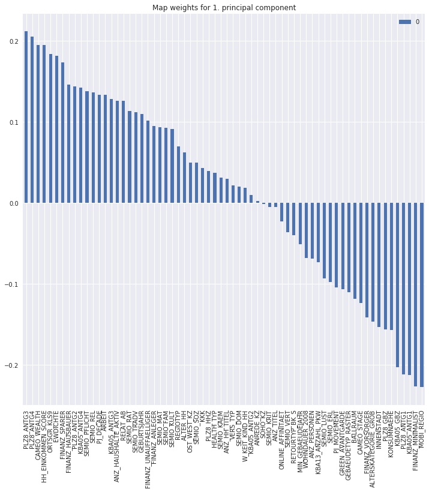

```python
# Plot bar graph
component.plot.bar()
plt.title('Map weights for 1. principal component')
```

```python
# Map weights for the second principal component to corresponding feature names
# and then print the linked values, sorted by weight.

# Call function to extract component
component = investigate_pca(azdias, pca, 1)
# Display values
component
```

|  | 0 |
| --- | --- |
| ALTERSKATEGORIE_GROB | 0.2299 |
| FINANZ_VORSORGER | 0.2132 |
| SEMIO_ERL | 0.1954 |
| SEMIO_LUST | 0.1638 |
| RETOURTYP_BK_S | 0.1628 |
| FINANZ_HAUSBAUER | 0.1347 |
| W_KEIT_KIND_HH | 0.1305 |
| PLZ8_ANTG3 | 0.1220 |
| PLZ8_ANTG4 | 0.1168 |
| EWDICHTE | 0.1148 |
| ORTSGR_KLS9 | 0.1137 |
| CAMEO_WEALTH | 0.1013 |
| SEMIO_KRIT | 0.0969 |
| SEMIO_KAEM | 0.0932 |
| KBA05_ANTG4 | 0.0876 |
| ARBEIT | 0.0854 |
| PLZ8_ANTG2 | 0.0838 |
| HH_EINKOMMEN_SCORE | 0.0811 |
| RELAT_AB | 0.0810 |
| ANZ_HAUSHALTE_AKTIV | 0.0793 |
| ANREDE_KZ | 0.0669 |
| KBA05_ANTG3 | 0.0612 |
| SEMIO_DOM | 0.0521 |
| WOHNDAUER_2008 | 0.0500 |
| FINANZ_MINIMALIST | 0.0413 |
| ANZ_HH_TITEL | 0.0343 |
| OST_WEST_KZ | 0.0337 |
| VERS_TYP | 0.0326 |
| REGIOTYP | 0.0310 |
| PLZ8_HHZ | 0.0182 |
| ... | ... |
| GREEN_AVANTGARDE | -0.0305 |
| KBA13_ANZAHL_PKW | -0.0457 |
| HEALTH_TYP | -0.0523 |
| SEMIO_VERT | -0.0534 |
| MIN_GEBAEUDEJAHR | -0.0548 |
| GEBAEUDETYP_RASTER | -0.0581 |
| BALLRAUM | -0.0754 |
| SEMIO_SOZ | -0.0767 |
| ANZ_PERSONEN | -0.0782 |
| KONSUMNAEHE | -0.0901 |
| PLZ8_GBZ | -0.0930 |
| INNENSTADT | -0.0941 |
| KBA05_ANTG1 | -0.1083 |
| KBA05_GBZ | -0.1153 |
| PLZ8_ANTG1 | -0.1197 |
| MOBI_REGIO | -0.1199 |
| SEMIO_MAT | -0.1350 |
| SEMIO_FAM | -0.1464 |
| SEMIO_RAT | -0.1557 |
| ONLINE_AFFINITAET | -0.1709 |
| SEMIO_KULT | -0.1824 |
| ALTER_HH | -0.1928 |
| GEBURTSJAHR | -0.1943 |
| FINANZ_ANLEGER | -0.1973 |
| SEMIO_PFLICHT | -0.2001 |
| SEMIO_TRADV | -0.2060 |
| FINANZ_SPARER | -0.2119 |
| FINANZ_UNAUFFAELLIGER | -0.2134 |
| SEMIO_REL | -0.2174 |
| PJ_DECADE | -0.2389 |

66 rows × 1 columns

```
Text(0.5,1,'Map weights for 2. principal component')
```

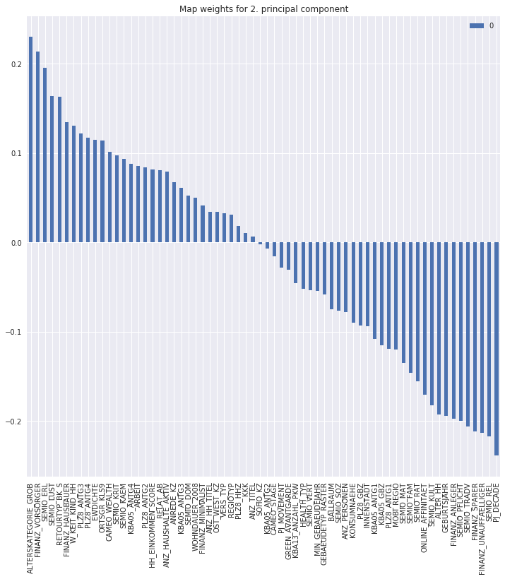

```python
# Plot bar graph
component.plot.bar()
plt.title('Map weights for 2. principal component')
```

```python
# Map weights for the third principal component to corresponding feature names
# and then print the linked values, sorted by weight.

# Call function to extract component
component = investigate_pca(azdias, pca, 2)
# Display values
component
```

|  | 0 |
| --- | --- |
| SEMIO_VERT | 0.3476 |
| SEMIO_SOZ | 0.2709 |
| SEMIO_FAM | 0.2671 |
| SEMIO_KULT | 0.2549 |
| FINANZ_MINIMALIST | 0.1449 |
| SEMIO_REL | 0.0982 |
| RETOURTYP_BK_S | 0.0950 |
| W_KEIT_KIND_HH | 0.0845 |
| FINANZ_VORSORGER | 0.0783 |
| SEMIO_MAT | 0.0731 |
| ALTERSKATEGORIE_GROB | 0.0499 |
| GREEN_AVANTGARDE | 0.0446 |
| SEMIO_LUST | 0.0443 |
| PJ_MOVEMENT | 0.0427 |
| PLZ8_ANTG4 | 0.0400 |
| ORTSGR_KLS9 | 0.0398 |
| PLZ8_ANTG3 | 0.0394 |
| EWDICHTE | 0.0392 |
| ARBEIT | 0.0301 |
| RELAT_AB | 0.0268 |
| PLZ8_ANTG2 | 0.0263 |
| WOHNDAUER_2008 | 0.0263 |
| CAMEO_WEALTH | 0.0241 |
| KBA05_ANTG4 | 0.0229 |
| ANZ_HAUSHALTE_AKTIV | 0.0218 |
| OST_WEST_KZ | 0.0141 |
| ANZ_HH_TITEL | 0.0106 |
| VERS_TYP | 0.0104 |
| ANZ_TITEL | 0.0088 |
| KBA05_ANTG3 | 0.0068 |
| ... | ... |
| KKK | -0.0128 |
| MIN_GEBAEUDEJAHR | -0.0138 |
| HEALTH_TYP | -0.0141 |
| HH_EINKOMMEN_SCORE | -0.0196 |
| KBA05_ANTG1 | -0.0203 |
| KBA13_ANZAHL_PKW | -0.0205 |
| KBA05_GBZ | -0.0221 |
| MOBI_REGIO | -0.0255 |
| GEBAEUDETYP_RASTER | -0.0273 |
| BALLRAUM | -0.0297 |
| KONSUMNAEHE | -0.0332 |
| PLZ8_GBZ | -0.0338 |
| INNENSTADT | -0.0371 |
| PLZ8_ANTG1 | -0.0407 |
| ONLINE_AFFINITAET | -0.0434 |
| FINANZ_HAUSBAUER | -0.0488 |
| SEMIO_PFLICHT | -0.0521 |
| SEMIO_TRADV | -0.0524 |
| ALTER_HH | -0.0688 |
| GEBURTSJAHR | -0.0717 |
| FINANZ_UNAUFFAELLIGER | -0.0778 |
| FINANZ_SPARER | -0.0826 |
| PJ_DECADE | -0.0870 |
| FINANZ_ANLEGER | -0.1683 |
| SEMIO_RAT | -0.1946 |
| SEMIO_ERL | -0.1973 |
| SEMIO_KRIT | -0.2811 |
| SEMIO_DOM | -0.3167 |
| SEMIO_KAEM | -0.3435 |
| ANREDE_KZ | -0.3727 |

66 rows × 1 columns

```
Text(0.5,1,'Map weights for 3. principal component')
```

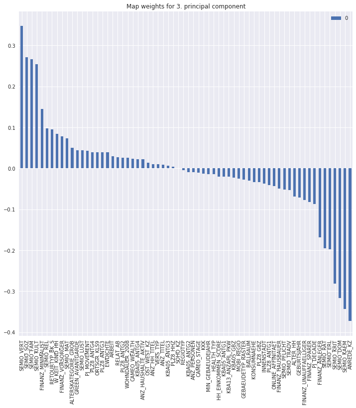

```python
# Plot bar graph
component.plot.bar()
plt.title('Map weights for 3. principal component')
```

### Discussion 2.3: Interpret Principal Components

**Dimension 1**

Dimension 1 is dominated by follwing top 5 features with positive and negative weights

| Rank | Positive | Negative |
| --- | --- | --- |
| 1 | PLZ8_ANTG3 | MOBI_REGIO |
| 2 | PLZ8_ANTG4 | FINANZ_MINIMALIST |
| 3 | CAMEO_WEALTH | KBA05_ANTG1 |
| 4 | HH_EINKOMMEN_SCORE | PLZ8_ANTG1 |
| 5 | ORTSGR_KLS9 | KBA05_GBZ |

In general, these features categorize the density of population as well as houshold income.

**Dimension 2**

Dimension 2 is dominated by follwing top 5 features with positive weights

| Rank | Positive | Negative |
| --- | --- | --- |
| 1 | ALTERSKATEGORIE_GROB | PJ_DECADE |
| 2 | FINANZ_VORSORGER | SEMIO_REL |
| 3 | SEMIO_ERL | FINANZ_UNAUFFAELLIGER |
| 4 | SEMIO_LUST | FINANZ_SPARER |
| 5 | RETOURTYP_BK_S | SEMIO_TRADV |

In general, these features categorize the personality typology as well as saving behaviour.

**Dimension 3**

Dimension 3 is dominated by follwing top 5 features with positive weights

| Rank | Positive | Negative |
| --- | --- | --- |
| 1 | SEMIO_VERT | ANREDE_KZ |
| 2 | SEMIO_SOZ | SEMIO_KAEM |
| 3 | SEMIO_FAM | SEMIO_DOM |
| 4 | SEMIO_KULT | SEMIO_KRIT |
| 5 | FINANZ_MINIMALIST | SEMIO_ERL |

In general, these features categorize the personality typology.

## Step 3: Clustering

### Step 3.1: Apply Clustering to General Population

You've assessed and cleaned the demographics data, then scaled and transformed them. Now, it's time to see how the data clusters in the principal components space. In this substep, you will apply k-means clustering to the dataset and use the average within-cluster distances from each point to their assigned cluster's centroid to decide on a number of clusters to keep.

- Use sklearn's KMeans class to perform k-means clustering on the PCA-transformed data.
- Then, compute the average difference from each point to its assigned cluster's center. **Hint**: The KMeans object's `.score()` method might be useful here, but note that in sklearn, scores tend to be defined so that larger is better. Try applying it to a small, toy dataset, or use an internet search to help your understanding.
- Perform the above two steps for a number of different cluster counts. You can then see how the average distance decreases with an increasing number of clusters. However, each additional cluster provides a smaller net benefit. Use this fact to select a final number of clusters in which to group the data. **Warning**: because of the large size of the dataset, it can take a long time for the algorithm to resolve. The more clusters to fit, the longer the algorithm will take. You should test for cluster counts through at least 10 clusters to get the full picture, but you shouldn't need to test for a number of clusters above about 30.
- Once you've selected a final number of clusters to use, re-fit a KMeans instance to perform the clustering operation. Make sure that you also obtain the cluster assignments for the general demographics data, since you'll be using them in the final Step 3.3.

```
Text(0,0.5,'Average within-Cluster Distances')
```

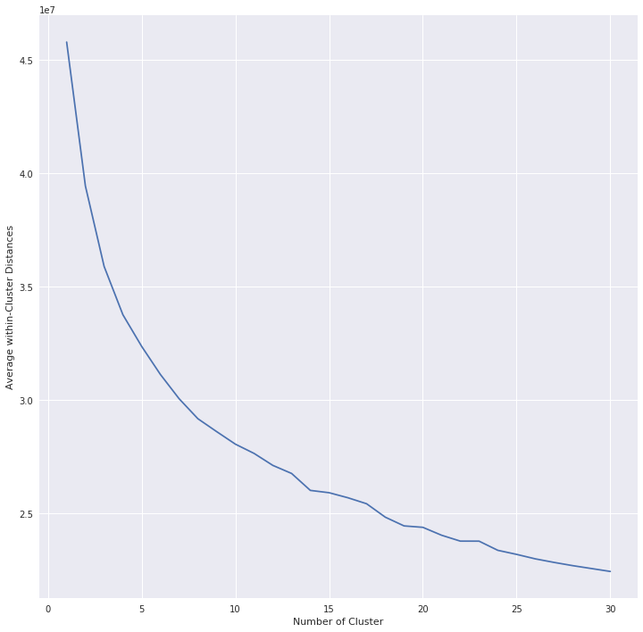

```python
# VERY LONG RUN TIME
# Create empty list
ave_dist_list = []

# Over a number of different cluster counts...
indices = range(1, 31, 1)
for idx in indices:
    # run k-means clustering on the data and...
    model = KMeans(n_clusters = idx)
    predictions = model.fit(azdias_pca)
    # compute the average within-cluster distances.
    ave_dist = np.abs(model.score(azdias_pca))
    # Append average distance
    ave_dist_list.append(ave_dist)

# Investigate the change in within-cluster distance across number of clusters.
# HINT: Use matplotlib's plot function to visualize this relationship.

plt.plot(indices, ave_dist_list)
plt.xlabel('Number of Cluster')
plt.ylabel('Average within-Cluster Distances')
```

```python
# Instatiate KMeans object
model_KMeans = KMeans(n_clusters = 10, random_state = 42)
# Fit and predict dataframe
azdias_predictions = model_KMeans.fit_predict(azdias_pca)
```

### Discussion 3.1: Apply Clustering to General Population

Average within-cluster distances as a function of number of cluster shows an exponential decay. Number of cluster = 10 seems to be a reasonable choice, as approx. 2/3 of the reduction of average within-cluster distances occurs between 1 and 10 number of clusters. I expect the computational cost to be proportional or even exponential to the number of clusters. So the lower 1/3 of the range of number of clusters seems to be a reasonable choice.

### Step 3.2: Apply All Steps to the Customer Data

Now that you have clusters and cluster centers for the general population, it's time to see how the customer data maps on to those clusters. Take care to not confuse this for re-fitting all of the models to the customer data. Instead, you're going to use the fits from the general population to clean, transform, and cluster the customer data. In the last step of the project, you will interpret how the general population fits apply to the customer data.

- Don't forget when loading in the customers data, that it is semicolon (`;`) delimited.
- Apply the same feature wrangling, selection, and engineering steps to the customer demographics using the `clean_data()` function you created earlier. (You can assume that the customer demographics data has similar meaning behind missing data patterns as the general demographics data.)
- Use the sklearn objects from the general demographics data, and apply their transformations to the customers data. That is, you should not be using a `.fit()` or `.fit_transform()` method to re-fit the old objects, nor should you be creating new sklearn objects! Carry the data through the feature scaling, PCA, and clustering steps, obtaining cluster assignments for all of the data in the customer demographics data.

```python
# Load in the customer demographics data.
customers = pd.read_csv('Udacity_CUSTOMERS_Subset.csv', sep = ';')
```

```python
# Apply preprocessing, feature transformation, and clustering from the general
# demographics onto the customer data, obtaining cluster predictions for the
# customer demographics data.

# Clean data by employing function clean_data() (see step 1.3)
customers_clean = clean_data(customers, feat_info)

# Transform data to imputer (see step 2.1)
customers_imputed = imputer.transform(customers_clean)

# Transform data to standard scaler (see step 2.1)
customer_scaled = standard_scaler.transform(customers_imputed)

# Transform data (see step 2.2)
customer_pca = pca.transform(customer_scaled)

# Predict dataframe
customer_predictions = model_KMeans.predict(customer_pca)
```

### Step 3.3: Compare Customer Data to Demographics Data

At this point, you have clustered data based on demographics of the general population of Germany, and seen how the customer data for a mail-order sales company maps onto those demographic clusters. In this final substep, you will compare the two cluster distributions to see where the strongest customer base for the company is.

Consider the proportion of persons in each cluster for the general population, and the proportions for the customers. If we think the company's customer base to be universal, then the cluster assignment proportions should be fairly similar between the two. If there are only particular segments of the population that are interested in the company's products, then we should see a mismatch from one to the other. If there is a higher proportion of persons in a cluster for the customer data compared to the general population (e.g. 5% of persons are assigned to a cluster for the general population, but 15% of the customer data is closest to that cluster's centroid) then that suggests the people in that cluster to be a target audience for the company. On the other hand, the proportion of the data in a cluster being larger in the general population than the customer data (e.g. only 2% of customers closest to a population centroid that captures 6% of the data) suggests that group of persons to be outside of the target demographics.

Take a look at the following points in this step:

- Compute the proportion of data points in each cluster for the general population and the customer data. Visualizations will be useful here: both for the individual dataset proportions, but also to visualize the ratios in cluster representation between groups. Seaborn's [`countplot()`](https://seaborn.pydata.org/generated/seaborn.countplot.html) or [`barplot()`](https://seaborn.pydata.org/generated/seaborn.barplot.html) function could be handy.
  - Recall the analysis you performed in step 1.1.3 of the project, where you separated out certain data points from the dataset if they had more than a specified threshold of missing values. If you found that this group was qualitatively different from the main bulk of the data, you should treat this as an additional data cluster in this analysis. Make sure that you account for the number of data points in this subset, for both the general population and customer datasets, when making your computations!
- Which cluster or clusters are overrepresented in the customer dataset compared to the general population? Select at least one such cluster and infer what kind of people might be represented by that cluster. Use the principal component interpretations from step 2.3 or look at additional components to help you make this inference. Alternatively, you can use the `.inverse_transform()` method of the PCA and StandardScaler objects to transform centroids back to the original data space and interpret the retrieved values directly.
- Perform a similar investigation for the underrepresented clusters. Which cluster or clusters are underrepresented in the customer dataset compared to the general population, and what kinds of people are typified by these clusters?

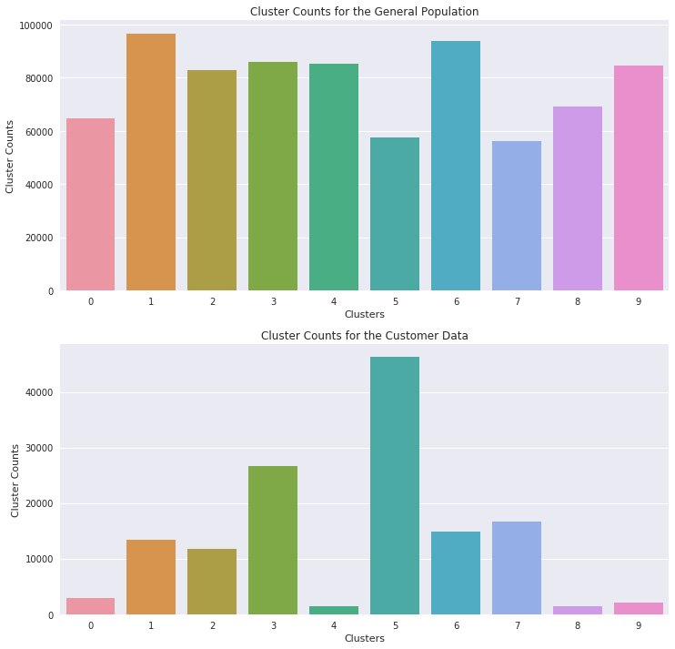

```python
# Compare the proportion of data in each cluster for the customer data to the
# proportion of data in each cluster for the general population.

# Create figure
fig = plt.figure()

# Create subplot with general population data
plt.subplot(2, 1, 1)
sns.countplot(azdias_predictions)
plt.title('Cluster Counts for the General Population')
plt.xlabel('Clusters')
plt.ylabel('Cluster Counts')

# Create subplot with customer data
plt.subplot(2, 1, 2)
sns.countplot(customer_predictions)
plt.title('Cluster Counts for the Customer Data')
plt.xlabel('Clusters')
plt.ylabel('Cluster Counts')

plt.show()
```

```python
# What kinds of people are part of a cluster that is overrepresented in the
# customer data compared to the general population?

# Cluster 5 is overrepresented in the in the customer dataset
# Get cluster center for cluster 5 and feed backward to get relevant features
cluster_centers_5 = model_KMeans.cluster_centers_[5]
pca_5 = pca.inverse_transform(cluster_centers_5)
customer_values_5 = standard_scaler.inverse_transform(pca_5)

# Create dataframe containing overrepresented customers
overrepresented_customers = pd.DataFrame(data = customer_values_5, index = customers_clean.columns).rename(columns = {0: 'overrepresented_customers'})
```

```python
# What kinds of people are part of a cluster that is underrepresented in the
# customer data compared to the general population?

# Cluster 4 is underrepresented in the in the customer dataset
# Get cluster center for cluster 4 and feed backward to get relevant features
cluster_centers_4 = model_KMeans.cluster_centers_[4]
pca_4 = pca.inverse_transform(cluster_centers_4)
customer_values_4 = standard_scaler.inverse_transform(pca_4)

# Create dataframe containing overrepresented customers
underrepresented_customers_4 = pd.DataFrame(data = customer_values_4, index = customers_clean.columns).rename(columns = {0: 'underrepresented_customers_4'})
```

```python
# What kinds of people are part of a cluster that is underrepresented in the
# customer data compared to the general population?

# Cluster 9 is underrepresented in the in the customer dataset
# Get cluster center for cluster 9 and feed backward to get relevant features
cluster_centers_9 = model_KMeans.cluster_centers_[9]
pca_9 = pca.inverse_transform(cluster_centers_9)
customer_values_9 = standard_scaler.inverse_transform(pca_9)

# Create dataframe containing overrepresented customers
underrepresented_customers_9 = pd.DataFrame(data = customer_values_9, index = customers_clean.columns).rename(columns = {0: 'underrepresented_customers_9'})
```

```python
# Get average of each feature of general population dataset
azdias_mean = azdias_clean.mean()

# Create dataframe
azdias_mean = pd.DataFrame(data = azdias_mean, index = azdias_clean.columns).rename(columns = {0: 'azdias_mean'})
```

```python
# Concat the two dataframes
predictions_concated = pd.concat([overrepresented_customers, azdias_mean, underrepresented_customers_4, underrepresented_customers_9], axis=1, sort=False)

predictions_concated.head()
```

|  | overrepresented_customers | azdias_mean | underrepresented_customers_4 | underrepresented_customers_9 |
| --- | --- | --- | --- | --- |
| ALTERSKATEGORIE_GROB | 3.304510 | 2.795878 | 1.734003 | 1.830468 |
| ANREDE_KZ | 1.050739 | 1.521039 | 2.003918 | 1.968833 |
| FINANZ_MINIMALIST | 4.853439 | 3.051280 | 1.195707 | 2.277137 |
| FINANZ_SPARER | 1.579038 | 2.711399 | 4.275819 | 4.027243 |
| FINANZ_VORSORGER | 4.232039 | 3.438115 | 2.198910 | 2.234749 |

```python
# Extract list of indices of dataframe
index_list = predictions_concated.index.tolist()

print(index_list)
```

```
['ALTERSKATEGORIE_GROB', 'ANREDE_KZ', 'FINANZ_MINIMALIST', 'FINANZ_SPARER', 'FINANZ_VORSORGER', 'FINANZ_ANLEGER', 'FINANZ_UNAUFFAELLIGER', 'FINANZ_HAUSBAUER', 'GEBURTSJAHR', 'GREEN_AVANTGARDE', 'HEALTH_TYP', 'RETOURTYP_BK_S', 'SEMIO_SOZ', 'SEMIO_FAM', 'SEMIO_REL', 'SEMIO_MAT', 'SEMIO_VERT', 'SEMIO_L…
```

```python
# Get the values for specific features
predictions_concated.iloc[index_list.index('ALTERSKATEGORIE_GROB')]
```

```
overrepresented_customers       3.304510
azdias_mean                     2.795878
underrepresented_customers_4    1.734003
underrepresented_customers_9    1.830468
Name: ALTERSKATEGORIE_GROB, dtype: float64
```

```python
# Get the values for specific features
predictions_concated.iloc[index_list.index('KBA05_ANTG1')]
```

```
overrepresented_customers       2.686980
azdias_mean                     1.494979
underrepresented_customers_4    0.392950
underrepresented_customers_9    2.234889
Name: KBA05_ANTG1, dtype: float64
```

```python
# Get the values for specific features
predictions_concated.iloc[index_list.index('KBA05_ANTG2')]
```

```
overrepresented_customers       1.148695
azdias_mean                     1.265865
underrepresented_customers_4    1.295690
underrepresented_customers_9    1.315538
Name: KBA05_ANTG2, dtype: float64
```

```python
# Get the values for specific features
predictions_concated.iloc[index_list.index('KBA05_ANTG3')]
```

```
overrepresented_customers       0.097283
azdias_mean                     0.625263
underrepresented_customers_4    1.165699
underrepresented_customers_9    0.275614
Name: KBA05_ANTG3, dtype: float64
```

```python
# Get the values for specific features
predictions_concated.iloc[index_list.index('KBA05_ANTG4')]
```

```
overrepresented_customers       0.012429
azdias_mean                     0.305736
underrepresented_customers_4    0.622097
underrepresented_customers_9    0.054135
Name: KBA05_ANTG4, dtype: float64
```

```python
# Get the values for specific features
predictions_concated.iloc[index_list.index('CAMEO_WEALTH')]
```

```
overrepresented_customers       2.144905
azdias_mean                     3.274449
underrepresented_customers_4    4.350716
underrepresented_customers_9    2.517613
Name: CAMEO_WEALTH, dtype: float64
```

```python
# Get the values for specific features
predictions_concated.iloc[index_list.index('HH_EINKOMMEN_SCORE')]
```

```
overrepresented_customers       2.445540
azdias_mean                     4.440805
underrepresented_customers_4    5.617487
underrepresented_customers_9    4.056645
Name: HH_EINKOMMEN_SCORE, dtype: float64
```

```python
# Get the values for specific features
predictions_concated.iloc[index_list.index('RELAT_AB')]
```

```
overrepresented_customers       2.916426
azdias_mean                     3.079253
underrepresented_customers_4    3.748218
underrepresented_customers_9    2.490149
Name: RELAT_AB, dtype: float64
```

```python
# Get the values for specific features
predictions_concated.iloc[index_list.index('ARBEIT')]
```

```
overrepresented_customers       3.033790
azdias_mean                     3.174327
underrepresented_customers_4    3.665202
underrepresented_customers_9    2.746587
Name: ARBEIT, dtype: float64
```

```python
# Get the values for specific features
predictions_concated.iloc[index_list.index('KKK')]
```

```
overrepresented_customers       2.171267
azdias_mean                     2.725313
underrepresented_customers_4    2.871476
underrepresented_customers_9    2.642712
Name: KKK, dtype: float64
```

```python
# Get the values for specific features
predictions_concated.iloc[index_list.index('KBA13_ANZAHL_PKW')]
```

```
overrepresented_customers       687.051055
azdias_mean                     618.717544
underrepresented_customers_4    521.904112
underrepresented_customers_9    702.160784
Name: KBA13_ANZAHL_PKW, dtype: float64
```

```python
# Get the values for specific features
predictions_concated.iloc[index_list.index('BALLRAUM')]
```

```
overrepresented_customers       4.043018
azdias_mean                     4.145784
underrepresented_customers_4    3.103983
underrepresented_customers_9    5.014776
Name: BALLRAUM, dtype: float64
```

```python
# Get the values for specific features
predictions_concated.iloc[index_list.index('EWDICHTE')]
```

```
overrepresented_customers       3.980167
azdias_mean                     3.950160
underrepresented_customers_4    5.187681
underrepresented_customers_9    2.982660
Name: EWDICHTE, dtype: float64
```

```python
# Get the values for specific features
predictions_concated.iloc[index_list.index('INNENSTADT')]
```

```
overrepresented_customers       4.561586
azdias_mean                     4.540083
underrepresented_customers_4    3.363201
underrepresented_customers_9    5.456764
Name: INNENSTADT, dtype: float64
```

```python
# Get the values for specific features
predictions_concated.iloc[index_list.index('ORTSGR_KLS9')]
```

```
overrepresented_customers       5.380905
azdias_mean                     5.307504
underrepresented_customers_4    6.982145
underrepresented_customers_9    3.947999
Name: ORTSGR_KLS9, dtype: float64
```

### Discussion 3.3: Compare Customer Data to Demographics Data

Following table summarizes the data from specific features of cluster 4, cluster 5 and cluster 9 in order to infer what kind of people might be represented by these clusters by comparing these values with the category defintions in Data_Directory.md.

| Feature | Overrepresented | Ave. Population | Underrepresented | Underrepresented |
| --- | --- | --- | --- | --- |
| Cluster | 5 | Reference | 4 | 9 |
| ALTERSKATEGORIE_GROB | 3.30 | 2.79 | 1.73 | 1.83 |
| KBA05_ANTG1 | 2.69 | 1.49 | 0.39 | 2.23 |
| KBA05_ANTG2 | 1.14 | 1.27 | 1.30 | 1.32 |
| KBA05_ANTG3 | 0.10 | 0.62 | 1.17 | 0.27 |
| KBA05_ANTG4 | 0.01 | 0.31 | 0.62 | 0.05 |
| CAMEO_WEALTH | 2.14 | 3.27 | 4.35 | 2.52 |
| HH_EINKOMMEN_SCORE | 2.45 | 4.44 | 5.62 | 4.06 |
| BALLRAUM | 4.04 | 4.14 | 3.10 | 5.01 |
| EWDICHTE | 3.98 | 3.95 | 5.19 | 2.98 |
| INNENSTADT | 4.56 | 4.54 | 3.36 | 5.45 |
| ORTSGR_KLS9 | 5.38 | 5.31 | 6.98 | 3.95 |

**Cluster 5** is **overrepresented** in the customer dataset compared to the general population dataset. This overrepresented customer group is populated by **middle-aged** people, living in **prosperous, high-income households** and has a **high share living in 1-2 family homes** compared to the general population. In more details:

- This overrepresented customer segment is mainly populated by 46 to 60 years old people, thus slightly older then the general population, and quite older than the underrepresented customer group, which is either younger than 30 or between 30 to 45 years old ('ALTERSKATEGORIE_GROB' = 3.30 compared to 1.73).
- This overrepresented customer segment mainly contains customers living in a prosperous household with high to very high income ('CAMEO_WEALTH' = 2.14, HH_EINKOMMEN_SCORE = 2.45).
- This overrepresented customer segment contains a high share of customers living in 1-2 family homes ('KBA05_ANTG1' = 2.69).
- The distance to the nearest urban center of the overrepresented customer segment is average compared to the general population ('BALLRAUM' = 4.04 compared to 4.14).
- This overrepresented customer segment is living in average densely populated areas ('EWDICHTE' = 3.98 compared to 3.95)

**Cluster 4** is **underrepresented** in the customer dataset compared to the general population dataset. This underrepresented customer group is **quite younger**, living in **less affluent, lower income households** and lives in **highly densely populated areas** compared to the general population. In more details:

- This underrepresented customer segment is mainly populated by either younger than 30 or between 30 to 45 years old people, thus quite younger than the general population and even more younger than the overrepresented customer group ('ALTERSKATEGORIE_GROB' = 1.73 compared to 2.79).
- This underrepresented customer segment mainly contains customers living in less affluent households with lower incomes ('CAMEO_WEALTH' = 4.35, HH_EINKOMMEN_SCORE = 5.62).
- This underrepresented customer segment contains an above average share of customers living in 6 to 10 family homes compared to the general population ('KBA05_ANTG3' = 1.17 compared to 0.62).
- The distance to the nearest urban center of the underrepresented customer segment is below average compared to the general population ('BALLRAUM' = 3.10 compared to 4.14).
- This underrepresented customer segment lives in highly densely populated areas ('EWDICHTE' = 5.19 compared to 3.95)

**Cluster 9** is **underrepresented** in the customer dataset compared to the general population dataset. This underrepresented customer group is **quite younger**, living in **comfortable to prosperous, average-income households** and lives in **lower densely populated areas** compared to the general population. In more details:

- This underrepresented customer segment is mainly populated by either younger than 30 or between 30 to 45 years old people, thus quite younger than the general population and even more younger than the overrepresented customer group ('ALTERSKATEGORIE_GROB' = 1.83 compared to 2.79).
- This underrepresented customer segment mainly contains customers living in comfortable to prosperous households with average income ('CAMEO_WEALTH' = 2.52, HH_EINKOMMEN_SCORE = 4.06).
- This underrepresented customer segment mainly lives in 1-2 family homes ('KBA05_ANTG1' = 2.23).
- The distance to the nearest urban center of this underrepresented customer segment is above average compared to the general population ('BALLRAUM' = 5.01 compared to 4.14).
- This underrepresented customer segment lives in lower densely populated areas ('EWDICHTE' = 2.98 compared to 3.95)

> Congratulations on making it this far in the project! Before you finish, make sure to check through the entire notebook from top to bottom to make sure that your analysis follows a logical flow and all of your findings are documented in **Discussion** cells. Once you've checked over all of your work, you should export the notebook as an HTML document to submit for evaluation. You can do this from the menu, navigating to **File -> Download as -> HTML (.html)**. You will submit both that document and this notebook for your project submission.